# Comparative analysis of Metaheuristics Algorithms to solve Optimization Problems

## 1 Objective:

The purpose of this project is to explore and compare Metaheuristics Algorithms to solve Optimization Problems.

### 1.1 What is an optimization problem?

An optimization problem is defined by Russell and Norvig (2010) as a problem in which "the aim is to find the best state according to an objective function." [1] Optimization problems can be divided into two categories depending on whether the variables are continuous or discrete. An optimization problem with discrete variables is known as a discrete optimization. In a discrete optimization problem, we are looking for an object such as an integer, permutation or graph from a countable set. Problems with continuous variables include constrained problems and multimodal problems. [2]

For this study I have considered/modified three typical optimization problems which **maximize** the fitness function

- **Kanpsack Problem:** Given a set of items, each with a weight and a value, determine the number of each item to include in a collection so that the total weight is less than or equal to a given limit and the total value is as large as possible. While the decision problem is NP-complete, the optimization problem is NP-hard. [3]
- **8 Queens:** In chess, the queen is the most powerful piece on the board. It can attack any piece in the same row, column or diagonal. In the 8-Queens problem, you are given a chessboard with eight queens (and no other pieces) and the aim is to place the queens on the board so that none of them can attack each other (Russell and Norvig (2010). This is a NP-Complete [4]
- **Travelling Sales Person**(modified): The travelling salesperson problem (TSP) is a classic optimization problem where the goal is to determine the **longest** tour of a collection of n “cities” (i.e. nodes), starting and ending in the same city and visiting all of the other cities exactly once. In such a situation, a solution can be represented by a vector of n integers, each in the range 0 to n-1, specifying the order in which the cities should be visited. TSP is an NP-hard problem, meaning that, for larger values of n, it is not feasible to evaluate every possible problem solution within a reasonable period of time. Consequently, TSPs are well suited to solving using randomized optimization algorithms. [5]

### 1.2 Approaches to solve Optimization Problems

To solve the optimization problems, we a choice to implement Exact algorithms or Metaheuristic algorithms.  
Exact algorithms consider entire solution spaces in order to give a global optima/minima whereas metaheuristic algorithms consider parts of the solution space and try to reach the best possible optima/minima.  
For NP-hard problems, Exact algorithms take huge amount of computation time and hence it is not feasible to implement them. Metaheuristic algorithms are used when it's extremely difficult to an optimal solution due to model complexity or huge search space. These algorithms are also used when best possible sub-optimal solution is preferred in short amout of times.

Analysis is carried out on the following four Metaheuristic algorithms -

- **Random Hill Climbing:** Algorithm iteratively does hill-climbing, each time with a random initial condition. The best condition is kept: if a new run of hill climbing produces a better condition than the stored state, it replaces the stored state. Random-restart hill climbing is a surprisingly effective algorithm in many cases. It turns out that it is often better to spend CPU time exploring the space, than carefully optimizing from an initial condition. [6]
- **Simulated Annealing:** Algorithm uses probabilistic technique for approximating the global optimum of a given function. Specifically, it is a metaheuristic to approximate global optimization in a large search space for an optimization problem. It is often used when the search space is discrete [7]
- **Genetic Algorithm:** Algorithm is inspired by the process of natural selection that belongs to the larger class of evolutionary algorithms (EA). Genetic algorithms are commonly used to generate high-quality solutions to optimization and search problems by relying on biologically inspired operators such as mutation, crossover and selection. [8]
- **MIMIC:** Algorithm analyze the global structure of the optimization landscape. A novel and efficient algorithm for the estimation of the structure is derived. It uses knowledge of the structure to guide a randomized search through the solution space and, in turn, to refine our estimate of the structure. [9]

### 1.3 Libraries and Packages

This project uses mlrose library which implements some of the most common randomized optimization and search algorithms to a range of different optimization problems, over both discrete- and continuous-valued parameter spaces. Other standard packages are: numpy, pandas and matplotlib.  
mlrose library is available at: https://github.com/hiive/mlrose/tree/master

```python
import time
import mlrose
import numpy as np
import pandas as pd
from matplotlib import cm
import matplotlib.pyplot as plt
from mpl_toolkits.mplot3d import Axes3D
np.random.seed(11)
```

## 2. Knapsack Problem

**Number of objects:** 20  
**Object Weights & Values:** Weights of these 20 objects are generated randomly with uniform values between 1 and 15. Values of these 20 objects are generated randomly with uniform values between 10 and 1000.  
**Knapsack Capacity:** Maximum capacity of the Knapsack is limited to 60%. This maximum capacity of knapsack (W) is defined as a percentage of the total of the weights list. (W = max_weight_pct x total_weight).

```python
size=20
weights = np.random.uniform(low=1, high=15, size=size).astype('int')
values = np.random.uniform(low=10, high=1000, size=size).astype('int')
max_pct = 0.6
```

**Fitness Function:** Given a set of n items, where item i has known weight $w_{i}$ and known value $v_{i}$; and maximum knapsack capacity, W, the Knapsack fitness function evaluates the fitness of a state vector $x = [x_{0}, x_{1}, \ldots, x_{n-1}]$ as: \begin{equation*} Fitness(x) = \sum_{i = 0}^{n-1}v_{i}x_{i}, \text{ if} \sum_{i = 0}^{n-1}w_{i}x_{i} \leq W, \text{ and 0, otherwise,} \end{equation*} where $x_{i}$ denotes the number of copies of item i included in the knapsack. [10]

```python
fitness = mlrose.Knapsack(weights, values, max_weight_pct=max_pct)
problem = mlrose.DiscreteOpt(length = size, fitness_fn = fitness, maximize = True, max_val = 2)
```

### 2.1 Step 1: Measure Fitness with Default Parameters and variable Max_Attempts

All four algorithms were executed with default values of their hyperparameters except max_attempts. Default Parameters for each algorithms are:

- _random_hill*climb:* max_iters=np.inf and restarts=0
- _simulated*annealing:* max_iters=np.inf and schedule=GeomDecay
- _genetic*alg:* max_iters=np.inf, pop_size=200 and mutation_prob=0.1
- *mimic:* np.inf, pop_size=200 and keep_pct=0.2

```python
# Random Hill Climbing
algo_stats = []
for maxampts in range(10, 110, 40):
    t_start = time.time()*1000.0
    best_state, best_fitness, curve_vals = mlrose.random_hill_climb(problem,max_attempts=maxampts,curve=True,random_state=11)
    t_stop = time.time()*1000.0
    runtime = t_stop - t_start
    algo_stats.append(["Knapsack", "RHC", best_state, best_fitness, maxampts, curve_vals.size, curve_vals, runtime])

# Genetic Algorithm
for maxampts in range(10, 110, 40):
    t_start = time.time()*1000.0
    best_state, best_fitness, curve_vals = mlrose.genetic_alg(problem, max_attempts=maxampts,curve=True,random_state=11)
    t_stop = time.time()*1000.0
    runtime = t_stop - t_start
    algo_stats.append(["Knapsack", "GA", best_state, best_fitness, maxampts, curve_vals.size, curve_vals, runtime])

# Simulated Annealing
for maxampts in range(10, 110, 40):
    t_start = time.time()*1000.0
    best_state, best_fitness, curve_vals = mlrose.simulated_annealing(problem,max_attempts=maxampts,curve=True,random_state=11)
    t_stop = time.time()*1000.0
    runtime = t_stop - t_start
    algo_stats.append(["Knapsack", "SA", best_state, best_fitness, maxampts, curve_vals.size, curve_vals, runtime])

# MIMIC
for maxampts in range(10, 110, 40):
    t_start = time.time()*1000.0
    best_state, best_fitness, curve_vals = mlrose.mimic(problem,max_attempts=maxampts,curve=True,random_state=11)
    t_stop = time.time()*1000.0
    runtime = t_stop - t_start
    algo_stats.append(["Knapsack", "MIMIC", best_state, best_fitness, maxampts, curve_vals.size, curve_vals, runtime])
```

```python
dfstats_KS = pd.DataFrame(algo_stats, columns=['Problem', 'Algorithm', 'Best_State', 'Best_Fitness', 'Max_Attempts', 'Iterations', 'Fitness', 'Runtime'])
```

```python
dfstats_KS.sort_values(['Best_Fitness', 'Iterations'], ascending=[False, True]).iloc[0]
```

```
Problem                                                  Knapsack
Algorithm                                                      GA
Best_State      [1, 1, 1, 0, 0, 0, 1, 1, 0, 1, 0, 1, 1, 1, 1, ...
Best_Fitness                                                 9542
Max_Attempts                                                   10
Iterations                                                     30
Fitness         [7909.0, 7909.0, 8122.0, 8897.0, 8897.0, 9081....
Runtime                                                   552.025
Name: 3, dtype: object
```

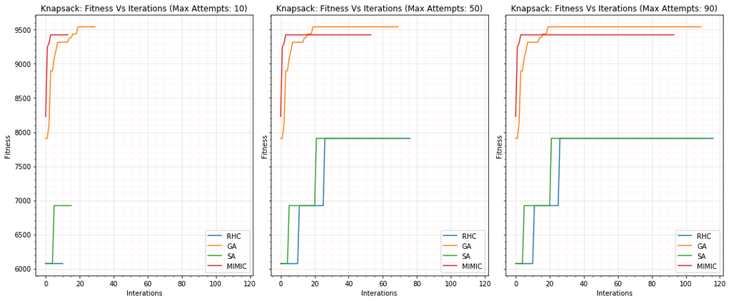

```python
fig, axs = plt.subplots(1,3, figsize=(15, 6), facecolor='w', edgecolor='k', sharex=True, sharey=True)

fig.tight_layout()
for ax, maxampts in zip(axs.ravel(), range(10, 110, 40)):
    for i in range(0, dfstats_KS[dfstats_KS['Max_Attempts']==maxampts].shape[0]):
        ax.plot(dfstats_KS[dfstats_KS['Max_Attempts']==maxampts].iloc[i]['Fitness'], label=dfstats_KS[dfstats_KS['Max_Attempts']==maxampts].iloc[i]['Algorithm'])
        ax.set_title('Knapsack: Fitness Vs Iterations (Max Attempts: '+str(maxampts)+')')
        ax.legend(loc='lower right')
        ax.set_xlabel('Interations')
        ax.set_ylabel('Fitness')
        ax.minorticks_on()
        ax.grid(b=True, which='major', color='k', linestyle='-', alpha=0.1)
        ax.grid(b=True, which='minor', color='r', linestyle='-', alpha=0.05)
```

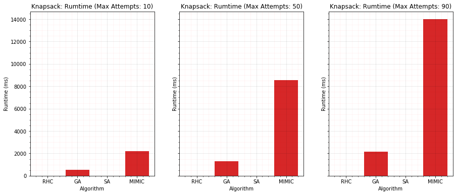

```python
fig, axs = plt.subplots(1,3, figsize=(15, 6), facecolor='w', edgecolor='k', sharex=True, sharey=True)
# fig.tight_layout()
for ax, maxampts in zip(axs.ravel(), range(10, 110, 40)):
    for i in range(0, dfstats_KS[dfstats_KS['Max_Attempts']==maxampts].shape[0]):
        ax.bar(dfstats_KS[dfstats_KS['Max_Attempts']==maxampts]['Algorithm'],dfstats_KS[dfstats_KS['Max_Attempts']==maxampts]['Runtime'])
        ax.set_title('Knapsack: Rumtime (Max Attempts: '+str(maxampts)+')')
        ax.set_xlabel('Algorithm')
        ax.set_ylabel('Runtime (ms)')
        ax.minorticks_on()
        ax.grid(b=True, which='major', color='k', linestyle='-', alpha=0.1)
        ax.grid(b=True, which='minor', color='r', linestyle='-', alpha=0.05)
```

```python
dfstats_KS
```

|  | Problem | Algorithm | Best_State | Best_Fitness | Max_Attempts | Iterations | Fitness | Runtime |
| --- | --- | --- | --- | --- | --- | --- | --- | --- |
| 0 | Knapsack | RHC | [1, 1, 0, 1, 0, 1, 1, 0, 1, 1, 0, 0, 1, 0, 0, ... | 6074.0 | 10 | 11 | [6074.0, 6074.0, 6074.0, 6074.0, 6074.0, 6074.... | 0.978027 |
| 1 | Knapsack | RHC | [1, 1, 0, 1, 0, 1, 1, 0, 1, 1, 0, 1, 1, 0, 0, ... | 7909.0 | 50 | 77 | [6074.0, 6074.0, 6074.0, 6074.0, 6074.0, 6074.... | 3.020020 |
| 2 | Knapsack | RHC | [1, 1, 0, 1, 0, 1, 1, 0, 1, 1, 0, 1, 1, 0, 0, ... | 7909.0 | 90 | 117 | [6074.0, 6074.0, 6074.0, 6074.0, 6074.0, 6074.... | 3.987061 |
| 3 | Knapsack | GA | [1, 1, 1, 0, 0, 0, 1, 1, 0, 1, 0, 1, 1, 1, 1, ... | 9542.0 | 10 | 30 | [7909.0, 7909.0, 8122.0, 8897.0, 8897.0, 9081.... | 552.025146 |
| 4 | Knapsack | GA | [1, 1, 1, 0, 0, 0, 1, 1, 0, 1, 0, 1, 1, 1, 1, ... | 9542.0 | 50 | 70 | [7909.0, 7909.0, 8122.0, 8897.0, 8897.0, 9081.... | 1298.338135 |
| 5 | Knapsack | GA | [1, 1, 1, 0, 0, 0, 1, 1, 0, 1, 0, 1, 1, 1, 1, ... | 9542.0 | 90 | 110 | [7909.0, 7909.0, 8122.0, 8897.0, 8897.0, 9081.... | 2145.956055 |
| 6 | Knapsack | SA | [1, 1, 0, 1, 0, 1, 1, 0, 1, 1, 0, 1, 1, 0, 0, ... | 6923.0 | 10 | 16 | [6074.0, 6074.0, 6074.0, 6074.0, 6074.0, 6923.... | 0.000000 |
| 7 | Knapsack | SA | [1, 1, 0, 1, 0, 1, 1, 0, 1, 1, 0, 1, 1, 0, 0, ... | 7909.0 | 50 | 72 | [6074.0, 6074.0, 6074.0, 6074.0, 6074.0, 6923.... | 10.103516 |
| 8 | Knapsack | SA | [1, 1, 0, 1, 0, 1, 1, 0, 1, 1, 0, 1, 1, 0, 0, ... | 7909.0 | 90 | 112 | [6074.0, 6074.0, 6074.0, 6074.0, 6074.0, 6923.... | 0.000000 |
| 9 | Knapsack | MIMIC | [1, 1, 1, 0, 1, 0, 1, 1, 0, 0, 0, 1, 1, 1, 1, ... | 9425.0 | 10 | 14 | [8230.0, 9246.0, 9303.0, 9425.0, 9425.0, 9425.... | 2205.150635 |
| 10 | Knapsack | MIMIC | [1, 1, 1, 0, 1, 0, 1, 1, 0, 0, 0, 1, 1, 1, 1, ... | 9425.0 | 50 | 54 | [8230.0, 9246.0, 9303.0, 9425.0, 9425.0, 9425.... | 8556.741211 |
| 11 | Knapsack | MIMIC | [1, 1, 1, 0, 1, 0, 1, 1, 0, 0, 0, 1, 1, 1, 1, ... | 9425.0 | 90 | 94 | [8230.0, 9246.0, 9303.0, 9425.0, 9425.0, 9425.... | 13994.631348 |

**Step 1 Observation:** *Genetic Algorithm* perfromed the best with highest fitness of 9542.0 where as *Random Hill Climbing* perfromed worst the among four algorithms. *Genetic Algorithm* converged in 30 iterations with 10 max attempts. *MIMIC* was the second best perfromer with fitness of 9425.0. Fitness of *Simulated Annealing* improved with increase in the max attempts

### 2.2 Step 2: Hyper Parameter Tuning

Following hyperparameters were tuned for each algorithms:

- _random_hill*climb:* restarts
- _simulated*annealing:* schedule
- _genetic*alg:* pop_size and mutation_prob
- *mimic:* pop_size and keep_pct

Following hyperparameters were used based on the observations from step 1:

```python
# Random Hill Climbing - Restart
algo_stats = []
for rstrt in (0, 1, 2, 3, 4, 5):
    t_start = time.time()*1000.0
    best_state, best_fitness, curve_vals = mlrose.random_hill_climb(problem,max_attempts=50,restarts=rstrt,curve=True,random_state=11)
    t_stop = time.time()*1000.0
    runtime = t_stop - t_start
    algo_stats.append(["Knapsack", "RHC", best_state, best_fitness, rstrt, curve_vals.size, curve_vals, runtime])
```

```python
dfstats_KS_RHC_Restart = pd.DataFrame(algo_stats, columns=['Problem', 'Algorithm', 'Best_State', 'Best_Fitness', 'Restarts', 'Iterations', 'Fitness', 'Runtime'])
```

```python
dfstats_KS_RHC_Restart.sort_values(['Best_Fitness', 'Iterations'], ascending=[False, True]).iloc[0]
```

```
Problem                                                  Knapsack
Algorithm                                                     RHC
Best_State      [1, 1, 0, 0, 1, 0, 1, 1, 0, 1, 1, 1, 0, 1, 1, ...
Best_Fitness                                                 9245
Restarts                                                        2
Iterations                                                     96
Fitness         [6045.0, 6045.0, 6894.0, 7497.0, 8295.0, 8901....
Runtime                                                   9.96289
Name: 2, dtype: object
```

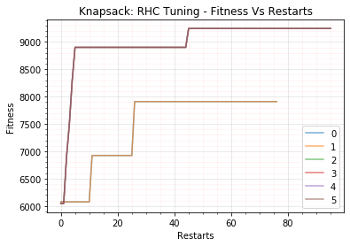

```python
for i in range(0, dfstats_KS_RHC_Restart.shape[0]):
    plt.plot(dfstats_KS_RHC_Restart.iloc[i]['Fitness'], label=dfstats_KS_RHC_Restart.iloc[i]['Restarts'], alpha=0.6)

plt.title('Knapsack: RHC Tuning - Fitness Vs Restarts')
plt.legend(loc='lower right')
plt.xlabel('Restarts')
plt.ylabel('Fitness')
plt.minorticks_on()
plt.grid(b=True, which='major', color='k', linestyle='-', alpha=0.1)
plt.grid(b=True, which='minor', color='r', linestyle='-', alpha=0.05)
plt.show()
```

```python
# Genetic Algorithm - Mutation Prob.
algo_stats = []
for mutprob in np.arange(0.1, 1, 0.1):
    t_start = time.time()*1000.0
    best_state, best_fitness, curve_vals = mlrose.genetic_alg(problem,max_attempts=10,mutation_prob=mutprob,curve=True,random_state=11)
    t_stop = time.time()*1000.0
    runtime = t_stop - t_start
    algo_stats.append(["Knapsack", "GA", best_state, best_fitness, round(mutprob, 2), curve_vals.size, curve_vals, runtime])
```

```python
dfstats_KS_GA_MutProb = pd.DataFrame(algo_stats, columns=['Problem', 'Algorithm', 'Best_State', 'Best_Fitness', 'Mutation_Prob', 'Iterations', 'Fitness', 'Runtime'])
```

```python
dfstats_KS_GA_MutProb.sort_values(['Best_Fitness', 'Iterations'], ascending=[False, True]).iloc[0]
```

```
Problem                                                   Knapsack
Algorithm                                                       GA
Best_State       [1, 1, 1, 0, 0, 0, 1, 1, 0, 1, 0, 1, 1, 1, 1, ...
Best_Fitness                                                  9542
Mutation_Prob                                                  0.8
Iterations                                                      19
Fitness          [8297.0, 8297.0, 8604.0, 8611.0, 8819.0, 9203....
Runtime                                                     305.37
Name: 7, dtype: object
```

```python
dfstats_KS_GA_MutProb
```

|  | Problem | Algorithm | Best_State | Best_Fitness | Mutation_Prob | Iterations | Fitness | Runtime |
| --- | --- | --- | --- | --- | --- | --- | --- | --- |
| 0 | Knapsack | GA | [1, 1, 1, 0, 0, 0, 1, 1, 0, 1, 0, 1, 1, 1, 1, ... | 9542.0 | 0.1 | 30 | [7909.0, 7909.0, 8122.0, 8897.0, 8897.0, 9081.... | 568.508301 |
| 1 | Knapsack | GA | [1, 1, 1, 0, 0, 0, 1, 1, 0, 1, 0, 1, 1, 1, 1, ... | 9542.0 | 0.2 | 20 | [8181.0, 8257.0, 8521.0, 8885.0, 9074.0, 9074.... | 361.992920 |
| 2 | Knapsack | GA | [1, 1, 1, 0, 0, 0, 1, 1, 0, 1, 0, 1, 1, 1, 1, ... | 9542.0 | 0.3 | 30 | [8220.0, 8678.0, 8678.0, 8678.0, 9178.0, 9178.... | 535.926758 |
| 3 | Knapsack | GA | [1, 1, 1, 0, 0, 0, 1, 1, 0, 1, 0, 1, 1, 1, 1, ... | 9542.0 | 0.4 | 24 | [7802.0, 8174.0, 8174.0, 9279.0, 9279.0, 9279.... | 416.733643 |
| 4 | Knapsack | GA | [1, 1, 1, 0, 0, 0, 1, 1, 0, 1, 0, 1, 1, 1, 1, ... | 9542.0 | 0.5 | 22 | [7721.0, 8442.0, 8532.0, 8979.0, 9261.0, 9277.... | 384.197998 |
| 5 | Knapsack | GA | [1, 1, 1, 0, 0, 0, 1, 1, 0, 1, 0, 1, 1, 1, 1, ... | 9542.0 | 0.6 | 24 | [8171.0, 9000.0, 9000.0, 9000.0, 9000.0, 9000.... | 404.295654 |
| 6 | Knapsack | GA | [1, 1, 1, 0, 0, 0, 1, 1, 0, 1, 0, 1, 1, 1, 1, ... | 9542.0 | 0.7 | 21 | [8309.0, 8427.0, 8681.0, 9207.0, 9207.0, 9207.... | 351.807861 |
| 7 | Knapsack | GA | [1, 1, 1, 0, 0, 0, 1, 1, 0, 1, 0, 1, 1, 1, 1, ... | 9542.0 | 0.8 | 19 | [8297.0, 8297.0, 8604.0, 8611.0, 8819.0, 9203.... | 305.370361 |
| 8 | Knapsack | GA | [1, 1, 1, 0, 0, 0, 1, 1, 0, 1, 0, 1, 1, 1, 1, ... | 9542.0 | 0.9 | 21 | [7907.0, 8627.0, 8714.0, 8714.0, 9085.0, 9085.... | 334.584717 |

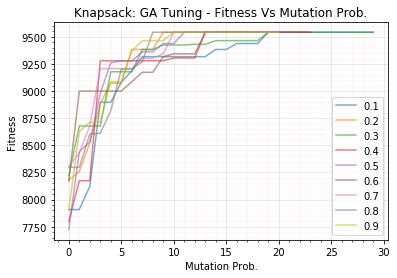

```python
for i in range(0, dfstats_KS_GA_MutProb.shape[0]):
    plt.plot(dfstats_KS_GA_MutProb.iloc[i]['Fitness'], label=dfstats_KS_GA_MutProb.iloc[i]['Mutation_Prob'], alpha=0.6)

plt.title('Knapsack: GA Tuning - Fitness Vs Mutation Prob.')
plt.legend(loc='lower right')
plt.xlabel('Mutation Prob.')
plt.ylabel('Fitness')
plt.minorticks_on()
plt.grid(b=True, which='major', color='k', linestyle='-', alpha=0.1)
plt.grid(b=True, which='minor', color='r', linestyle='-', alpha=0.05)
plt.show()
```

```python
# Genetic Algorithm - Population Size.
algo_stats = []
for popsize in range(100, 600, 100):
    t_start = time.time()*1000.0
    best_state, best_fitness, curve_vals = mlrose.genetic_alg(problem,max_attempts=10,pop_size=popsize,mutation_prob=0.8,curve=True,random_state=11)
    t_stop = time.time()*1000.0
    runtime = t_stop - t_start
    algo_stats.append(["Knapsack", "GA", best_state, best_fitness, popsize, curve_vals.size, curve_vals, runtime])
```

```python
dfstats_KS_GA_PopSz = pd.DataFrame(algo_stats, columns=['Problem', 'Algorithm', 'Best_State', 'Best_Fitness', 'Pop_Size', 'Iterations', 'Fitness', 'Runtime'])
```

```python
dfstats_KS_GA_PopSz.sort_values(['Best_Fitness', 'Iterations'], ascending=[False, True]).iloc[0]
```

```
Problem                                                  Knapsack
Algorithm                                                      GA
Best_State      [1, 1, 1, 0, 0, 0, 1, 1, 0, 1, 0, 1, 1, 1, 1, ...
Best_Fitness                                                 9542
Pop_Size                                                      200
Iterations                                                     19
Fitness         [8297.0, 8297.0, 8604.0, 8611.0, 8819.0, 9203....
Runtime                                                   311.022
Name: 1, dtype: object
```

```python
dfstats_KS_GA_PopSz
```

|  | Problem | Algorithm | Best_State | Best_Fitness | Pop_Size | Iterations | Fitness | Runtime |
| --- | --- | --- | --- | --- | --- | --- | --- | --- |
| 0 | Knapsack | GA | [1, 1, 0, 0, 0, 0, 1, 1, 0, 1, 0, 1, 1, 1, 1, ... | 9438.0 | 100 | 16 | [7721.0, 8197.0, 8920.0, 8920.0, 8960.0, 9438.... | 143.099121 |
| 1 | Knapsack | GA | [1, 1, 1, 0, 0, 0, 1, 1, 0, 1, 0, 1, 1, 1, 1, ... | 9542.0 | 200 | 19 | [8297.0, 8297.0, 8604.0, 8611.0, 8819.0, 9203.... | 311.021729 |
| 2 | Knapsack | GA | [1, 1, 1, 0, 0, 0, 1, 1, 0, 1, 0, 1, 1, 1, 1, ... | 9542.0 | 300 | 21 | [8003.0, 8439.0, 8885.0, 9001.0, 9438.0, 9438.... | 520.622314 |
| 3 | Knapsack | GA | [1, 1, 1, 0, 0, 0, 1, 1, 0, 1, 0, 1, 1, 1, 1, ... | 9542.0 | 400 | 20 | [8834.0, 8834.0, 8834.0, 9094.0, 9311.0, 9425.... | 689.510742 |
| 4 | Knapsack | GA | [1, 1, 1, 0, 0, 0, 1, 1, 0, 1, 0, 1, 1, 1, 1, ... | 9542.0 | 500 | 22 | [8834.0, 8964.0, 8964.0, 8964.0, 9383.0, 9383.... | 919.705078 |

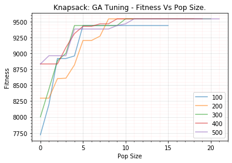

```python
for i in range(0, dfstats_KS_GA_PopSz.shape[0]):
    plt.plot(dfstats_KS_GA_PopSz.iloc[i]['Fitness'], label=dfstats_KS_GA_PopSz.iloc[i]['Pop_Size'], alpha=0.6)

plt.title('Knapsack: GA Tuning - Fitness Vs Pop Size.')
plt.legend(loc='lower right')
plt.xlabel('Pop Size')
plt.ylabel('Fitness')
plt.minorticks_on()
plt.grid(b=True, which='major', color='k', linestyle='-', alpha=0.1)
plt.grid(b=True, which='minor', color='r', linestyle='-', alpha=0.05)
plt.show()
```

```python
# Simulated Annealing - Decay.

expdecay = mlrose.ExpDecay(init_temp=1.0, exp_const=0.005, min_temp=0.001)
arithdecay = mlrose.ArithDecay(init_temp=1.0, decay=0.0001, min_temp=0.001)
geomdecay = mlrose.GeomDecay(init_temp=1.0, decay=0.99, min_temp=0.001)

algo_stats = []
for decay in [expdecay, arithdecay, geomdecay]:
    t_start = time.time()*1000.0
    best_state, best_fitness, curve_vals = mlrose.simulated_annealing(problem,max_attempts=50,schedule=decay,curve=True,random_state=11)
    t_stop = time.time()*1000.0
    runtime = t_stop - t_start
    algo_stats.append(["Knapsack", "SA", best_state, best_fitness, type(decay).__name__, curve_vals.size, curve_vals, runtime])
```

```python
dfstats_KS_SA_Decay = pd.DataFrame(algo_stats, columns=['Problem', 'Algorithm', 'Best_State', 'Best_Fitness', 'Decay_Type', 'Iterations', 'Fitness', 'Runtime'])
```

```python
dfstats_KS_SA_Decay.sort_values(['Best_Fitness', 'Iterations','Runtime'], ascending=[False, True, True]).iloc[0]
```

```
Problem                                                  Knapsack
Algorithm                                                      SA
Best_State      [1, 1, 0, 1, 0, 1, 1, 0, 1, 1, 0, 1, 1, 0, 0, ...
Best_Fitness                                                 7909
Decay_Type                                              GeomDecay
Iterations                                                     72
Fitness         [6074.0, 6074.0, 6074.0, 6074.0, 6074.0, 6923....
Runtime                                                   3.50488
Name: 2, dtype: object
```

```python
dfstats_KS_SA_Decay
```

|  | Problem | Algorithm | Best_State | Best_Fitness | Decay_Type | Iterations | Fitness | Runtime |
| --- | --- | --- | --- | --- | --- | --- | --- | --- |
| 0 | Knapsack | SA | [1, 1, 0, 1, 0, 1, 1, 0, 1, 1, 0, 1, 1, 0, 0, ... | 7909.0 | ExpDecay | 72 | [6074.0, 6074.0, 6074.0, 6074.0, 6074.0, 6923.... | 3.956787 |
| 1 | Knapsack | SA | [1, 1, 0, 1, 0, 1, 1, 0, 1, 1, 0, 1, 1, 0, 0, ... | 7909.0 | ArithDecay | 72 | [6074.0, 6074.0, 6074.0, 6074.0, 6074.0, 6923.... | 4.505859 |
| 2 | Knapsack | SA | [1, 1, 0, 1, 0, 1, 1, 0, 1, 1, 0, 1, 1, 0, 0, ... | 7909.0 | GeomDecay | 72 | [6074.0, 6074.0, 6074.0, 6074.0, 6074.0, 6923.... | 3.504883 |

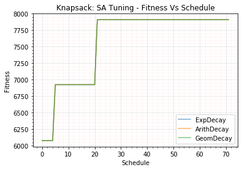

```python
for i in range(0, dfstats_KS_SA_Decay.shape[0]):
    plt.plot(dfstats_KS_SA_Decay.iloc[i]['Fitness'], label=dfstats_KS_SA_Decay.iloc[i]['Decay_Type'], alpha=0.6)

plt.title('Knapsack: SA Tuning - Fitness Vs Schedule')
plt.legend(loc='lower right')
plt.xlabel('Schedule')
plt.ylabel('Fitness')
plt.minorticks_on()
plt.grid(b=True, which='major', color='k', linestyle='-', alpha=0.1)
plt.grid(b=True, which='minor', color='r', linestyle='-', alpha=0.05)
plt.show()
```

```python
# MIMIC - Keep Pct.
algo_stats = []
for keeppct in (0.1, 0.25, 0.5, 0.75, 1):
    t_start = time.time()*1000.0
    best_state, best_fitness, curve_vals = mlrose.mimic(problem,max_attempts=10,keep_pct=keeppct,curve=True,random_state=11)
    t_stop = time.time()*1000.0
    runtime = t_stop - t_start
    algo_stats.append(["Knapsack", "MIMIC", best_state, best_fitness, keeppct, curve_vals.size, curve_vals, runtime])
```

```python
dfstats_KS_MIMIC_KeepPct = pd.DataFrame(algo_stats, columns=['Problem', 'Algorithm', 'Best_State', 'Best_Fitness', 'Keep_Pct', 'Iterations', 'Fitness', 'Runtime'])
```

```python
dfstats_KS_MIMIC_KeepPct.sort_values(['Best_Fitness', 'Iterations'], ascending=[False, True]).iloc[0]
```

```
Problem                                                  Knapsack
Algorithm                                                   MIMIC
Best_State      [1, 1, 1, 0, 0, 0, 1, 1, 0, 1, 0, 1, 1, 1, 1, ...
Best_Fitness                                                 9542
Keep_Pct                                                      0.1
Iterations                                                     15
Fitness         [8908.0, 9191.0, 9383.0, 9383.0, 9542.0, 9542....
Runtime                                                   2268.82
Name: 0, dtype: object
```

```python
dfstats_KS_MIMIC_KeepPct
```

|  | Problem | Algorithm | Best_State | Best_Fitness | Keep_Pct | Iterations | Fitness | Runtime |
| --- | --- | --- | --- | --- | --- | --- | --- | --- |
| 0 | Knapsack | MIMIC | [1, 1, 1, 0, 0, 0, 1, 1, 0, 1, 0, 1, 1, 1, 1, ... | 9542.0 | 0.10 | 15 | [8908.0, 9191.0, 9383.0, 9383.0, 9542.0, 9542.... | 2268.820068 |
| 1 | Knapsack | MIMIC | [1, 1, 1, 0, 0, 0, 1, 1, 0, 1, 0, 1, 1, 1, 1, ... | 9542.0 | 0.25 | 16 | [8917.0, 9030.0, 9317.0, 9383.0, 9383.0, 9542.... | 2450.481689 |
| 2 | Knapsack | MIMIC | [1, 1, 1, 0, 0, 0, 1, 1, 0, 1, 0, 1, 1, 1, 1, ... | 9542.0 | 0.50 | 19 | [8916.0, 8916.0, 8916.0, 9305.0, 9305.0, 9425.... | 2965.149414 |
| 3 | Knapsack | MIMIC | [1, 1, 1, 1, 0, 0, 1, 1, 0, 0, 1, 1, 0, 1, 1, ... | 9317.0 | 0.75 | 22 | [8128.0, 8404.0, 8404.0, 8791.0, 8819.0, 8819.... | 3352.147217 |
| 4 | Knapsack | MIMIC | [1, 1, 1, 0, 0, 0, 1, 1, 0, 1, 1, 1, 1, 0, 1, ... | 8545.0 | 1.00 | 12 | [8089.0, 8545.0, 8545.0, 8545.0, 8545.0, 8545.... | 1841.812744 |

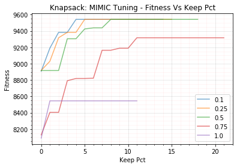

```python
for i in range(0, dfstats_KS_MIMIC_KeepPct.shape[0]):
    plt.plot(dfstats_KS_MIMIC_KeepPct.iloc[i]['Fitness'], label=dfstats_KS_MIMIC_KeepPct.iloc[i]['Keep_Pct'], alpha=0.6)

plt.title('Knapsack: MIMIC Tuning - Fitness Vs Keep Pct')
plt.legend(loc='lower right')
plt.xlabel('Keep Pct')
plt.ylabel('Fitness')
plt.minorticks_on()
plt.grid(b=True, which='major', color='k', linestyle='-', alpha=0.1)
plt.grid(b=True, which='minor', color='r', linestyle='-', alpha=0.05)
plt.show()
```

```python
# MIMIC - Pop Size.
algo_stats = []
for popsz in range(100, 600, 100):
    t_start = time.time()*1000.0
    best_state, best_fitness, curve_vals = mlrose.mimic(problem,max_attempts=10,keep_pct=0.1,pop_size=popsz,curve=True,random_state=11)
    t_stop = time.time()*1000.0
    runtime = t_stop - t_start
    algo_stats.append(["Knapsack", "MIMIC", best_state, best_fitness, popsz, curve_vals.size, curve_vals, runtime])
```

```python
dfstats_KS_MIMIC_PopSz = pd.DataFrame(algo_stats, columns=['Problem', 'Algorithm', 'Best_State', 'Best_Fitness', 'Pop_Size', 'Iterations', 'Fitness', 'Runtime'])
```

```python
dfstats_KS_MIMIC_PopSz.sort_values(['Best_Fitness', 'Iterations'], ascending=[False, True]).iloc[0]
```

```
Problem                                                  Knapsack
Algorithm                                                   MIMIC
Best_State      [1, 1, 1, 0, 0, 0, 1, 1, 0, 1, 0, 1, 1, 1, 1, ...
Best_Fitness                                                 9542
Pop_Size                                                      400
Iterations                                                     12
Fitness         [9039.0, 9542.0, 9542.0, 9542.0, 9542.0, 9542....
Runtime                                                   1914.46
Name: 3, dtype: object
```

```python
dfstats_KS_MIMIC_PopSz
```

|  | Problem | Algorithm | Best_State | Best_Fitness | Pop_Size | Iterations | Fitness | Runtime |
| --- | --- | --- | --- | --- | --- | --- | --- | --- |
| 0 | Knapsack | MIMIC | [1, 1, 1, 1, 1, 0, 1, 1, 0, 1, 0, 1, 1, 0, 1, ... | 9037.0 | 100 | 12 | [8825.0, 9037.0, 9037.0, 9037.0, 9037.0, 9037.... | 1819.995361 |
| 1 | Knapsack | MIMIC | [1, 1, 1, 0, 0, 0, 1, 1, 0, 1, 0, 1, 1, 1, 1, ... | 9542.0 | 200 | 15 | [8908.0, 9191.0, 9383.0, 9383.0, 9542.0, 9542.... | 2226.401123 |
| 2 | Knapsack | MIMIC | [1, 1, 1, 0, 0, 0, 1, 1, 0, 1, 0, 1, 1, 1, 1, ... | 9542.0 | 300 | 13 | [8491.0, 9183.0, 9542.0, 9542.0, 9542.0, 9542.... | 1995.062744 |
| 3 | Knapsack | MIMIC | [1, 1, 1, 0, 0, 0, 1, 1, 0, 1, 0, 1, 1, 1, 1, ... | 9542.0 | 400 | 12 | [9039.0, 9542.0, 9542.0, 9542.0, 9542.0, 9542.... | 1914.460449 |
| 4 | Knapsack | MIMIC | [1, 1, 1, 0, 0, 0, 1, 1, 0, 1, 0, 1, 1, 1, 1, ... | 9542.0 | 500 | 13 | [9125.0, 9343.0, 9542.0, 9542.0, 9542.0, 9542.... | 2069.629639 |

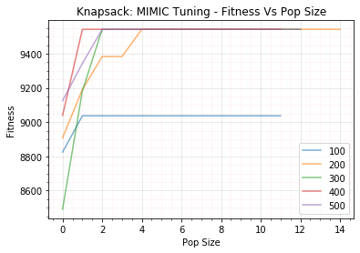

```python
for i in range(0, dfstats_KS_MIMIC_PopSz.shape[0]):
    plt.plot(dfstats_KS_MIMIC_PopSz.iloc[i]['Fitness'], label=dfstats_KS_MIMIC_PopSz.iloc[i]['Pop_Size'], alpha=0.6)

plt.title('Knapsack: MIMIC Tuning - Fitness Vs Pop Size')
plt.legend(loc='lower right')
plt.xlabel('Pop Size')
plt.ylabel('Fitness')
plt.minorticks_on()
plt.grid(b=True, which='major', color='k', linestyle='-', alpha=0.1)
plt.grid(b=True, which='minor', color='r', linestyle='-', alpha=0.05)
plt.show()
```

**Step 2 Observation:** Optimal hyperparameters for each algorithms:

- _random_hill*climb:* max_attempts=50 and restarts=2
- _simulated*annealing:* max_attempts=10 and schedule=GeomDecay  
  (Fitness with all schedules were same but algorithm runtime was lowest with GeomDecay)
- _genetic*alg:* max_attempts=50, pop_size=200 and mutation_prob=0.8
- *mimic:* max_attempts=10, pop_size=400 and keep_pct=0.1

### 2.3 Step 3: Measure Fitness on Tuned Algorithms

All four algorithms were executed for optimal values of their hyperparameters observed in step 2. Hyper Parameters for each algorithms are:

- _random_hill*climb:* max_iters=np.inf, max_attempts=50 and restarts=2
- _simulated*annealing:* max_iters=np.inf, max_attempts=10 and schedule=GeomDecay
- _genetic*alg:* max_iters=np.inf, max_attempts=50, pop_size=200 and mutation_prob=0.8
- *mimic:* np.inf, max_attempts=10, pop_size=400 and keep_pct=0.1

```python
# Random Hill Climbing
algo_stats = []
t_start = time.time()*1000.0
best_state, best_fitness, curve_vals = mlrose.random_hill_climb(problem,max_attempts=50,restarts=2, curve=True,random_state=11)
t_stop = time.time()*1000.0
runtime = t_stop - t_start
algo_stats.append(["Knapsack", "RHC", best_state, best_fitness, 50, curve_vals.size, curve_vals, runtime])

# Genetic Algorithm
t_start = time.time()*1000.0
best_state, best_fitness, curve_vals = mlrose.genetic_alg(problem, max_attempts=50,pop_size=200,mutation_prob=0.8,curve=True,random_state=11)
t_stop = time.time()*1000.0
runtime = t_stop - t_start
algo_stats.append(["Knapsack", "GA", best_state, best_fitness, 10, curve_vals.size, curve_vals, runtime])

# Simulated Annealing
t_start = time.time()*1000.0
best_state, best_fitness, curve_vals = mlrose.simulated_annealing(problem,max_attempts=10,schedule=geomdecay,curve=True,random_state=11)
t_stop = time.time()*1000.0
runtime = t_stop - t_start
algo_stats.append(["Knapsack", "SA", best_state, best_fitness, 50, curve_vals.size, curve_vals, runtime])

# MIMIC
t_start = time.time()*1000.0
best_state, best_fitness, curve_vals = mlrose.mimic(problem,max_attempts=10,keep_pct=0.1,pop_size=400,curve=True,random_state=11)
t_stop = time.time()*1000.0
runtime = t_stop - t_start
algo_stats.append(["Knapsack", "MIMIC", best_state, best_fitness, 10, curve_vals.size, curve_vals, runtime])
```

```python
dfstats_KS_Opt = pd.DataFrame(algo_stats, columns=['Problem', 'Algorithm', 'Best_State', 'Best_Fitness', 'Max_Attempts', 'Iterations', 'Fitness', 'Runtime'])
```

```python
dfstats_KS_Opt.sort_values(['Best_Fitness', 'Iterations'], ascending=[False, True]).iloc[0]
```

```
Problem                                                  Knapsack
Algorithm                                                   MIMIC
Best_State      [1, 1, 1, 0, 0, 0, 1, 1, 0, 1, 0, 1, 1, 1, 1, ...
Best_Fitness                                                 9542
Max_Attempts                                                   10
Iterations                                                     12
Fitness         [9039.0, 9542.0, 9542.0, 9542.0, 9542.0, 9542....
Runtime                                                   1855.07
Name: 3, dtype: object
```

```python
dfstats_KS_Opt
```

|  | Problem | Algorithm | Best_State | Best_Fitness | Max_Attempts | Iterations | Fitness | Runtime |
| --- | --- | --- | --- | --- | --- | --- | --- | --- |
| 0 | Knapsack | RHC | [1, 1, 0, 0, 1, 0, 1, 1, 0, 1, 1, 1, 0, 1, 1, ... | 9245.0 | 50 | 96 | [6045.0, 6045.0, 6894.0, 7497.0, 8295.0, 8901.... | 11.419678 |
| 1 | Knapsack | GA | [1, 1, 1, 0, 0, 0, 1, 1, 0, 1, 0, 1, 1, 1, 1, ... | 9542.0 | 10 | 59 | [8297.0, 8297.0, 8604.0, 8611.0, 8819.0, 9203.... | 961.205322 |
| 2 | Knapsack | SA | [1, 1, 0, 1, 0, 1, 1, 0, 1, 1, 0, 1, 1, 0, 0, ... | 6923.0 | 50 | 16 | [6074.0, 6074.0, 6074.0, 6074.0, 6074.0, 6923.... | 0.000000 |
| 3 | Knapsack | MIMIC | [1, 1, 1, 0, 0, 0, 1, 1, 0, 1, 0, 1, 1, 1, 1, ... | 9542.0 | 10 | 12 | [9039.0, 9542.0, 9542.0, 9542.0, 9542.0, 9542.... | 1855.067383 |

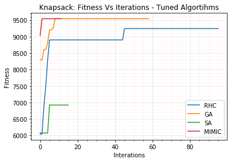

```python
for i in range(0, dfstats_KS_Opt.shape[0]):
    plt.plot(dfstats_KS_Opt.iloc[i]['Fitness'], label=dfstats_KS_Opt.iloc[i]['Algorithm'])

plt.title('Knapsack: Fitness Vs Iterations - Tuned Algortihms')
plt.legend(loc='lower right')
plt.xlabel('Interations')
plt.ylabel('Fitness')
plt.minorticks_on()
plt.grid(b=True, which='major', color='k', linestyle='-', alpha=0.1)
plt.grid(b=True, which='minor', color='r', linestyle='-', alpha=0.05)
plt.show()
```

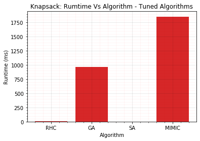

```python
for i in range(0, dfstats_KS_Opt.shape[0]):
    plt.bar(dfstats_KS_Opt['Algorithm'], dfstats_KS_Opt['Runtime'])

plt.title('Knapsack: Rumtime Vs Algorithm - Tuned Algorithms')
plt.xlabel('Algorithm')
plt.ylabel('Runtime (ms)')
plt.minorticks_on()
plt.grid(b=True, which='major', color='k', linestyle='-', alpha=0.1)
plt.grid(b=True, which='minor', color='r', linestyle='-', alpha=0.05)
```

**Step 3 Observation:** *Genetic Algorithm* and *MIMIC* both perfromed the best with highest fitness of 9542.0. Although *MIMIC* converged faster, runtime for *Genetic Algorithm* was almost half of *MIMIC*. As runtime in more important in this problem domain, we can say that *Genetic Algorithm* performed the best. *Simulated Annealing* was fastest to run but worst on fitness whereas *Random Hill Climbing* was distant thrid among four algorithms .

### 2.4 Step 4: Measure Fitness of Tuned Algorithms on Increased Complexity

Complexity of model was increased by increasing the number of items to 200.

```python
size=200
weights = np.random.uniform(low=1, high=15, size=size).astype('int')
values = np.random.uniform(low=10, high=1000, size=size).astype('int')
max_pct = 0.6
```

```python
fitness = mlrose.Knapsack(weights, values, max_weight_pct=max_pct)
problem = mlrose.DiscreteOpt(length = size, fitness_fn = fitness, maximize = True, max_val = 2)
```

All four algorithms were executed on complex Knapsack problem for optimal values of their hyperparameters observed in step 2. Max Iteration and Max Attempts were kept defualt. Hyper Parameters for each algorithms are:

- _random_hill*climb:* restarts=2
- _simulated*annealing:* schedule=GeomDecay
- _genetic*alg:* pop_size=200 and mutation_prob=0.8
- *mimic:* pop_size=400 and keep_pct=0.1

```python
# Random Hill Climbing
algo_stats = []
t_start = time.time()*1000.0
best_state, best_fitness, curve_vals = mlrose.random_hill_climb(problem, restarts=2, curve=True,random_state=11)
t_stop = time.time()*1000.0
runtime = t_stop - t_start
algo_stats.append(["Knapsack", "RHC", best_state, best_fitness, 10, curve_vals.size, curve_vals, runtime])

# Genetic Algorithm
t_start = time.time()*1000.0
best_state, best_fitness, curve_vals = mlrose.genetic_alg(problem,pop_size=200,mutation_prob=0.8,curve=True,random_state=11)
t_stop = time.time()*1000.0
runtime = t_stop - t_start
algo_stats.append(["Knapsack", "GA", best_state, best_fitness, 10, curve_vals.size, curve_vals, runtime])

# Simulated Annealing
t_start = time.time()*1000.0
best_state, best_fitness, curve_vals = mlrose.simulated_annealing(problem,schedule=geomdecay,curve=True,random_state=11)
t_stop = time.time()*1000.0
runtime = t_stop - t_start
algo_stats.append(["Knapsack", "SA", best_state, best_fitness, 10, curve_vals.size, curve_vals, runtime])

# MIMIC
t_start = time.time()*1000.0
best_state, best_fitness, curve_vals = mlrose.mimic(problem,keep_pct=0.1,pop_size=400,curve=True,random_state=11)
t_stop = time.time()*1000.0
runtime = t_stop - t_start
algo_stats.append(["Knapsack", "MIMIC", best_state, best_fitness, 10, curve_vals.size, curve_vals, runtime])
```

```python
dfstats_KS_Opt_Cmplx = pd.DataFrame(algo_stats, columns=['Problem', 'Algorithm', 'Best_State', 'Best_Fitness', 'Max_Attempts', 'Iterations', 'Fitness', 'Runtime'])
```

```python
dfstats_KS_Opt_Cmplx.sort_values(['Best_Fitness', 'Iterations'], ascending=[False, True]).iloc[0]
```

```
Problem                                                  Knapsack
Algorithm                                                      GA
Best_State      [1, 0, 1, 1, 0, 1, 1, 1, 0, 1, 0, 1, 1, 0, 1, ...
Best_Fitness                                                89092
Max_Attempts                                                   10
Iterations                                                    121
Fitness         [61079.0, 61079.0, 62733.0, 64366.0, 64450.0, ...
Runtime                                                   3301.36
Name: 1, dtype: object
```

```python
dfstats_KS_Opt_Cmplx
```

|  | Problem | Algorithm | Best_State | Best_Fitness | Max_Attempts | Iterations | Fitness | Runtime |
| --- | --- | --- | --- | --- | --- | --- | --- | --- |
| 0 | Knapsack | RHC | [0, 1, 1, 1, 0, 1, 0, 1, 0, 0, 1, 1, 0, 1, 1, ... | 60538.0 | 10 | 62 | [46410.0, 47140.0, 47585.0, 48121.0, 48121.0, ... | 10.994629 |
| 1 | Knapsack | GA | [1, 0, 1, 1, 0, 1, 1, 1, 0, 1, 0, 1, 1, 0, 1, ... | 89092.0 | 10 | 121 | [61079.0, 61079.0, 62733.0, 64366.0, 64450.0, ... | 3301.357178 |
| 2 | Knapsack | SA | [1, 1, 0, 1, 1, 1, 1, 0, 1, 1, 0, 0, 1, 0, 0, ... | 56206.0 | 10 | 39 | [49393.0, 49411.0, 49411.0, 49411.0, 49411.0, ... | 3.043213 |
| 3 | Knapsack | MIMIC | [1, 0, 1, 1, 0, 1, 1, 1, 0, 1, 0, 1, 1, 0, 1, ... | 86322.0 | 10 | 24 | [64250.0, 68910.0, 73372.0, 75215.0, 76447.0, ... | 487289.326416 |

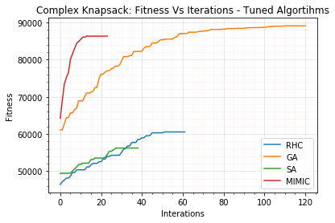

```python
for i in range(0, dfstats_KS_Opt_Cmplx.shape[0]):
    plt.plot(dfstats_KS_Opt_Cmplx.iloc[i]['Fitness'], label=dfstats_KS_Opt_Cmplx.iloc[i]['Algorithm'])

plt.title('Complex Knapsack: Fitness Vs Iterations - Tuned Algortihms')
plt.legend(loc='lower right')
plt.xlabel('Interations')
plt.ylabel('Fitness')
plt.minorticks_on()
plt.grid(b=True, which='major', color='k', linestyle='-', alpha=0.1)
plt.grid(b=True, which='minor', color='r', linestyle='-', alpha=0.05)
plt.show()
```

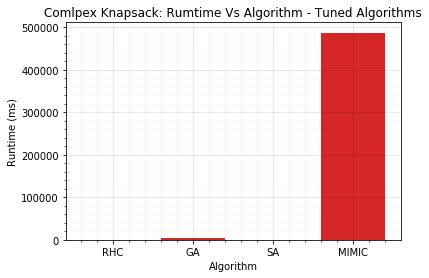

```python
for i in range(0, dfstats_KS_Opt_Cmplx.shape[0]):
    plt.bar(dfstats_KS_Opt_Cmplx['Algorithm'], dfstats_KS_Opt_Cmplx['Runtime'])

plt.title('Comlpex Knapsack: Rumtime Vs Algorithm - Tuned Algorithms')
plt.xlabel('Algorithm')
plt.ylabel('Runtime (ms)')
plt.minorticks_on()
plt.grid(b=True, which='major', color='k', linestyle='-', alpha=0.1)
plt.grid(b=True, which='minor', color='r', linestyle='-', alpha=0.05)
```

Comparision with perfromance in Step 3:  
As complexity of the problem increased *Genetic Algorithm* outperfromed *MIMIC*. Other trends such as runtime and iteration required to converge remained consistent.

**Strength of Genetic Algorithms:** The biggest benefit of Genetic Algorithm is the parallelism. This algorithm is less likely to stuck in the local optima because of the large number of instances in a search space. Genetic algorithm uses elitism to increase the selective pressure among the chromosomes which compete for survival across the search space. This approach ensurs global optima and high fitness level in the population.

Disadvantages of Genetic Algorithms: It may be difficult to select encoding and fitness function. Algorithm also has longer running time even on the smaller problems.

## 3 N Queens Problem

No of Queens: 8

```python
size=8
```

**Futness Function:** Objective of the 8-Queens problem is to find a state vector for which all pairs of queens do not attack each other. In this context, we could define our fitness function as evaluating the number of pairs of non-attacking queens for a given state and try to maximize this function. [11]

```python
# This function is copied from MLRose Tutorial
# https://mlrose.readthedocs.io/en/stable/source/tutorial1.html
def queens_max(state):
    fitness_cnt = 0
    for i in range(len(state) - 1):
        for j in range(i + 1, len(state)):
            if (state[j] != state[i]) and (state[j] != state[i] + (j - i)) and (state[j] != state[i] - (j - i)):
                fitness_cnt += 1
    return fitness_cnt

fitness = mlrose.CustomFitness(queens_max)
```

```python
fitness = mlrose.Queens()
problem = mlrose.DiscreteOpt(length = size, fitness_fn = fitness, maximize = True, max_val = size)
init_state = np.array([0, 0, 0, 0, 0, 0, 0, 0])
```

### 3.1 Step 1: Measure Fitness with Default Parameters and variable Max_Attempts

All four algorithms were executed with default values of their hyperparameters except max_attempts. Default Parameters for each algorithms are:

random_hill_climb: max_iters=np.inf and restarts=0  
simulated_annealing: max_iters=np.inf and schedule=GeomDecay  
genetic_alg: max_iters=np.inf, pop_size=200 and mutation_prob=0.1  
mimic: np.inf, pop_size=200 and keep_pct=0.2

```python
# Random Hill Climbing
algo_stats = []
for maxampts in range(10, 110, 40):
    t_start = time.time()*1000.0
    best_state, best_fitness, curve_vals = mlrose.random_hill_climb(problem,max_attempts=maxampts,curve=True,random_state=11)
    t_stop = time.time()*1000.0
    runtime = t_stop - t_start
    algo_stats.append(["8Queens", "RHC", best_state, best_fitness, maxampts, curve_vals.size, curve_vals, runtime])

# Genetic Algorithm
for maxampts in range(10, 110, 40):
    t_start = time.time()*1000.0
    best_state, best_fitness, curve_vals = mlrose.genetic_alg(problem, max_attempts=maxampts,curve=True,random_state=11)
    t_stop = time.time()*1000.0
    runtime = t_stop - t_start
    algo_stats.append(["8Queens", "GA", best_state, best_fitness, maxampts, curve_vals.size, curve_vals, runtime])

# Simulated Annealing
for maxampts in range(10, 110, 40):
    t_start = time.time()*1000.0
    best_state, best_fitness, curve_vals = mlrose.simulated_annealing(problem,max_attempts=maxampts,curve=True,random_state=11)
    t_stop = time.time()*1000.0
    runtime = t_stop - t_start
    algo_stats.append(["8Queens", "SA", best_state, best_fitness, maxampts, curve_vals.size, curve_vals, runtime])

# MIMIC
for maxampts in range(10, 110, 40):
    t_start = time.time()*1000.0
    best_state, best_fitness, curve_vals = mlrose.mimic(problem,max_attempts=maxampts,curve=True,random_state=11)
    t_stop = time.time()*1000.0
    runtime = t_stop - t_start
    algo_stats.append(["8Queens", "MIMIC", best_state, best_fitness, maxampts, curve_vals.size, curve_vals, runtime])
```

```python
dfstats_8Q = pd.DataFrame(algo_stats, columns=['Problem', 'Algorithm', 'Best_State', 'Best_Fitness', 'Max_Attempts', 'Iterations', 'Fitness', 'Runtime'])
```

```python
dfstats_8Q.sort_values(['Best_Fitness', 'Iterations'], ascending=[False, True]).iloc[0]
```

```
Problem                                                   8Queens
Algorithm                                                   MIMIC
Best_State                               [2, 7, 6, 5, 4, 3, 2, 1]
Best_Fitness                                                   23
Max_Attempts                                                   10
Iterations                                                     14
Fitness         [17.0, 18.0, 22.0, 23.0, 23.0, 23.0, 23.0, 23....
Runtime                                                   1224.65
Name: 9, dtype: object
```

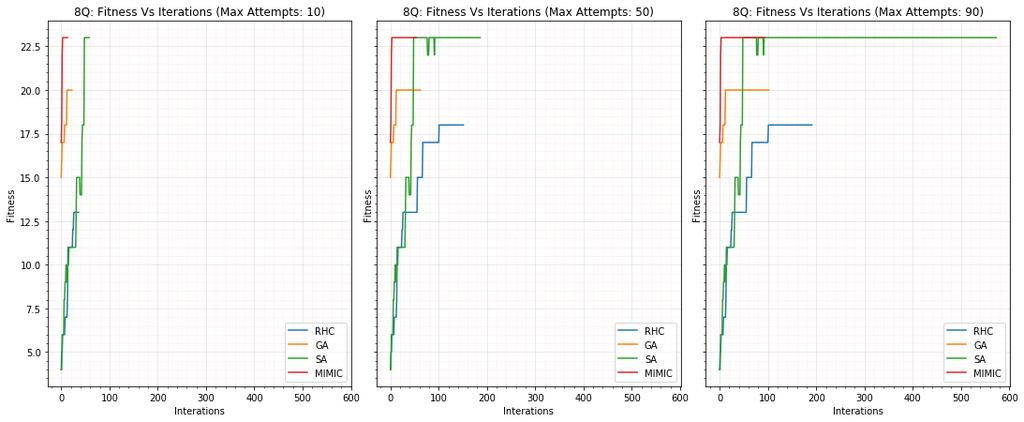

```python
fig, axs = plt.subplots(1,3, figsize=(15, 6), facecolor='w', edgecolor='k', sharex=True, sharey=True)

fig.tight_layout()
for ax, maxampts in zip(axs.ravel(), range(10, 110, 40)):
    for i in range(0, dfstats_8Q[dfstats_8Q['Max_Attempts']==maxampts].shape[0]):
        ax.plot(dfstats_8Q[dfstats_8Q['Max_Attempts']==maxampts].iloc[i]['Fitness'], label=dfstats_8Q[dfstats_8Q['Max_Attempts']==maxampts].iloc[i]['Algorithm'])
        ax.set_title('8Q: Fitness Vs Iterations (Max Attempts: '+str(maxampts)+')')
        ax.legend(loc='lower right')
        ax.set_xlabel('Interations')
        ax.set_ylabel('Fitness')
        ax.minorticks_on()
        ax.grid(b=True, which='major', color='k', linestyle='-', alpha=0.1)
        ax.grid(b=True, which='minor', color='r', linestyle='-', alpha=0.05)
```

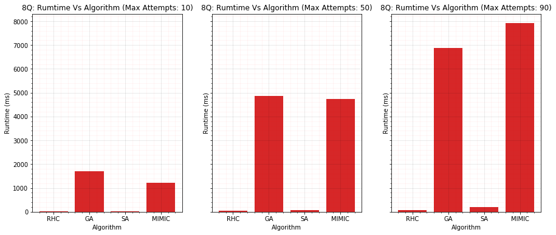

```python
fig, axs = plt.subplots(1,3, figsize=(15, 6), facecolor='w', edgecolor='k', sharex=True, sharey=True)
# fig.tight_layout()
for ax, maxampts in zip(axs.ravel(), range(10, 110, 40)):
    for i in range(0, dfstats_8Q[dfstats_8Q['Max_Attempts']==maxampts].shape[0]):
        ax.bar(dfstats_8Q[dfstats_8Q['Max_Attempts']==maxampts]['Algorithm'],dfstats_8Q[dfstats_8Q['Max_Attempts']==maxampts]['Runtime'])
        ax.set_title('8Q: Rumtime Vs Algorithm (Max Attempts: '+str(maxampts)+')')
        ax.set_xlabel('Algorithm')
        ax.set_ylabel('Runtime (ms)')
        ax.minorticks_on()
        ax.grid(b=True, which='major', color='k', linestyle='-', alpha=0.1)
        ax.grid(b=True, which='minor', color='r', linestyle='-', alpha=0.05)
```

```python
dfstats_8Q
```

|  | Problem | Algorithm | Best_State | Best_Fitness | Max_Attempts | Iterations | Fitness | Runtime |
| --- | --- | --- | --- | --- | --- | --- | --- | --- |
| 0 | 8Queens | RHC | [6, 7, 3, 0, 1, 2, 3, 4] | 13.0 | 10 | 37 | [4.0, 5.0, 5.0, 6.0, 6.0, 6.0, 6.0, 6.0, 7.0, ... | 15.946289 |
| 1 | 8Queens | RHC | [1, 2, 3, 0, 1, 2, 3, 4] | 18.0 | 50 | 152 | [4.0, 5.0, 5.0, 6.0, 6.0, 6.0, 6.0, 6.0, 7.0, ... | 53.858887 |
| 2 | 8Queens | RHC | [1, 2, 3, 0, 1, 2, 3, 4] | 18.0 | 90 | 192 | [4.0, 5.0, 5.0, 6.0, 6.0, 6.0, 6.0, 6.0, 7.0, ... | 67.332275 |
| 3 | 8Queens | GA | [5, 4, 3, 2, 1, 0, 3, 2] | 20.0 | 10 | 23 | [15.0, 16.0, 17.0, 17.0, 17.0, 17.0, 17.0, 18.... | 1702.480957 |
| 4 | 8Queens | GA | [5, 4, 3, 2, 1, 0, 3, 2] | 20.0 | 50 | 63 | [15.0, 16.0, 17.0, 17.0, 17.0, 17.0, 17.0, 18.... | 4856.270752 |
| 5 | 8Queens | GA | [5, 4, 3, 2, 1, 0, 3, 2] | 20.0 | 90 | 103 | [15.0, 16.0, 17.0, 17.0, 17.0, 17.0, 17.0, 18.... | 6867.147949 |
| 6 | 8Queens | SA | [6, 5, 4, 3, 2, 1, 0, 3] | 23.0 | 10 | 59 | [4.0, 4.0, 6.0, 6.0, 6.0, 6.0, 8.0, 8.0, 9.0, ... | 23.544922 |
| 7 | 8Queens | SA | [6, 5, 4, 3, 2, 1, 0, 1] | 23.0 | 50 | 187 | [4.0, 4.0, 6.0, 6.0, 6.0, 6.0, 8.0, 8.0, 9.0, ... | 61.991943 |
| 8 | 8Queens | SA | [6, 5, 4, 3, 2, 1, 0, 5] | 23.0 | 90 | 574 | [4.0, 4.0, 6.0, 6.0, 6.0, 6.0, 8.0, 8.0, 9.0, ... | 187.483887 |
| 9 | 8Queens | MIMIC | [2, 7, 6, 5, 4, 3, 2, 1] | 23.0 | 10 | 14 | [17.0, 18.0, 22.0, 23.0, 23.0, 23.0, 23.0, 23.... | 1224.647949 |
| 10 | 8Queens | MIMIC | [2, 7, 6, 5, 4, 3, 2, 1] | 23.0 | 50 | 54 | [17.0, 18.0, 22.0, 23.0, 23.0, 23.0, 23.0, 23.... | 4732.219971 |
| 11 | 8Queens | MIMIC | [2, 7, 6, 5, 4, 3, 2, 1] | 23.0 | 90 | 94 | [17.0, 18.0, 22.0, 23.0, 23.0, 23.0, 23.0, 23.... | 7919.883789 |

**Step 1 Observation:** Both *Simulated Annealing* and *MIMIC* performed the best with fitness score of 23 but *MIMIC* took less iterations to converge whereas *Simulated Annealing* was approx. 50 times faster than MIMIC. *Genetic Algorithm* ranked third with fitness score of 20 and *Random Hill Climbing* performed worst. Perfromance of *Random Hill Climbing* improved slightly with the increse in max attempts.

### 3.2 Step 2: Hyper Parameters Tuning

Following hyperparameters were tuned for each algorithms:

- _random_hill*climb:* restarts
- _simulated*annealing:* schedule
- _genetic*alg:* pop_size and mutation_prob
- *mimic:* pop_size and keep_pct

Following hyperparameters were used based on the observations from step 1:

- _random_hill*climb:* max_attempts=50
- _simulated*annealing:* max_attempts=10
- _genetic*alg:* max_attempts=10
- *mimic:* max_attempts=10

```python
# Random Hill Climbing - Restart
algo_stats = []
for rstrt in (0, 1, 2, 3, 4, 5):
    t_start = time.time()*1000.0
    best_state, best_fitness, curve_vals = mlrose.random_hill_climb(problem,max_attempts=50,restarts=rstrt,curve=True,random_state=11)
    t_stop = time.time()*1000.0
    runtime = t_stop - t_start
    algo_stats.append(["8Q", "RHC", best_state, best_fitness, rstrt, curve_vals.size, curve_vals, runtime])
```

```python
dfstats_8Q_RHC_Restart = pd.DataFrame(algo_stats, columns=['Problem', 'Algorithm', 'Best_State', 'Best_Fitness', 'Restarts', 'Iterations', 'Fitness', 'Runtime'])
```

```python
dfstats_8Q_RHC_Restart.sort_values(['Best_Fitness', 'Iterations'], ascending=[False, True]).iloc[0]
```

```
Problem                                                        8Q
Algorithm                                                     RHC
Best_State                               [6, 5, 4, 3, 2, 1, 0, 3]
Best_Fitness                                                   23
Restarts                                                        2
Iterations                                                    135
Fitness         [6.0, 9.0, 9.0, 9.0, 9.0, 9.0, 10.0, 10.0, 10....
Runtime                                                   112.205
Name: 2, dtype: object
```

```python
dfstats_8Q_RHC_Restart
```

|  | Problem | Algorithm | Best_State | Best_Fitness | Restarts | Iterations | Fitness | Runtime |
| --- | --- | --- | --- | --- | --- | --- | --- | --- |
| 0 | 8Q | RHC | [1, 2, 3, 0, 1, 2, 3, 4] | 18.0 | 0 | 152 | [4.0, 5.0, 5.0, 6.0, 6.0, 6.0, 6.0, 6.0, 7.0, ... | 43.381836 |
| 1 | 8Q | RHC | [1, 2, 3, 0, 1, 2, 3, 4] | 18.0 | 1 | 152 | [4.0, 5.0, 5.0, 6.0, 6.0, 6.0, 6.0, 6.0, 7.0, ... | 66.821777 |
| 2 | 8Q | RHC | [6, 5, 4, 3, 2, 1, 0, 3] | 23.0 | 2 | 135 | [6.0, 9.0, 9.0, 9.0, 9.0, 9.0, 10.0, 10.0, 10.... | 112.205322 |
| 3 | 8Q | RHC | [6, 5, 4, 3, 2, 1, 0, 3] | 23.0 | 3 | 135 | [6.0, 9.0, 9.0, 9.0, 9.0, 9.0, 10.0, 10.0, 10.... | 136.244385 |
| 4 | 8Q | RHC | [6, 5, 4, 3, 2, 1, 0, 3] | 23.0 | 4 | 135 | [6.0, 9.0, 9.0, 9.0, 9.0, 9.0, 10.0, 10.0, 10.... | 165.981934 |
| 5 | 8Q | RHC | [6, 5, 4, 3, 2, 1, 0, 3] | 23.0 | 5 | 135 | [6.0, 9.0, 9.0, 9.0, 9.0, 9.0, 10.0, 10.0, 10.... | 204.262451 |

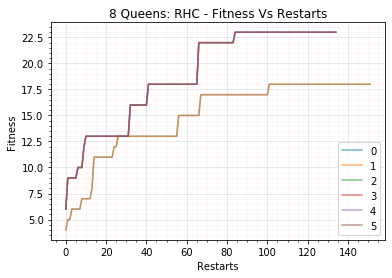

```python
for i in range(0, dfstats_8Q_RHC_Restart.shape[0]):
    plt.plot(dfstats_8Q_RHC_Restart.iloc[i]['Fitness'], label=dfstats_8Q_RHC_Restart.iloc[i]['Restarts'], alpha=0.6)

plt.title('8 Queens: RHC - Fitness Vs Restarts')
plt.legend(loc='lower right')
plt.xlabel('Restarts')
plt.ylabel('Fitness')
plt.minorticks_on()
plt.grid(b=True, which='major', color='k', linestyle='-', alpha=0.1)
plt.grid(b=True, which='minor', color='r', linestyle='-', alpha=0.05)
plt.show()
```

```python
# Genetic Algorithm - Mutation Prob.
algo_stats = []
for mutprob in (0.1, 0.25, 0.5):
    t_start = time.time()*1000.0
    best_state, best_fitness, curve_vals = mlrose.genetic_alg(problem,max_attempts=10,mutation_prob=mutprob,curve=True,random_state=11)
    t_stop = time.time()*1000.0
    runtime = t_stop - t_start
    algo_stats.append(["8Q", "GA", best_state, best_fitness, mutprob, curve_vals.size, curve_vals, runtime])
```

```python
dfstats_8Q_GA_MutProb = pd.DataFrame(algo_stats, columns=['Problem', 'Algorithm', 'Best_State', 'Best_Fitness', 'Mutation_Prob', 'Iterations', 'Fitness', 'Runtime'])
```

```python
dfstats_8Q_GA_MutProb.sort_values(['Best_Fitness', 'Iterations'], ascending=[False, True]).iloc[0]
```

```
Problem                                                         8Q
Algorithm                                                       GA
Best_State                                [0, 1, 2, 3, 4, 5, 6, 7]
Best_Fitness                                                    28
Mutation_Prob                                                  0.5
Iterations                                                      30
Fitness          [15.0, 15.0, 15.0, 15.0, 15.0, 15.0, 16.0, 18....
Runtime                                                    1748.22
Name: 2, dtype: object
```

```python
dfstats_8Q_GA_MutProb
```

|  | Problem | Algorithm | Best_State | Best_Fitness | Mutation_Prob | Iterations | Fitness | Runtime |
| --- | --- | --- | --- | --- | --- | --- | --- | --- |
| 0 | 8Q | GA | [5, 4, 3, 2, 1, 0, 3, 2] | 20.0 | 0.10 | 23 | [15.0, 16.0, 17.0, 17.0, 17.0, 17.0, 17.0, 18.... | 1335.559570 |
| 1 | 8Q | GA | [0, 1, 2, 3, 4, 5, 6, 7] | 28.0 | 0.25 | 37 | [14.0, 16.0, 16.0, 16.0, 16.0, 16.0, 17.0, 17.... | 2088.228027 |
| 2 | 8Q | GA | [0, 1, 2, 3, 4, 5, 6, 7] | 28.0 | 0.50 | 30 | [15.0, 15.0, 15.0, 15.0, 15.0, 15.0, 16.0, 18.... | 1748.221680 |

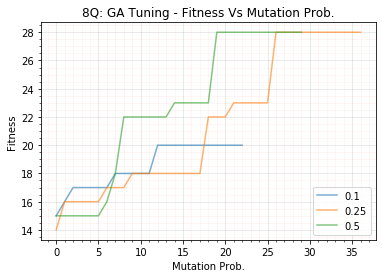

```python
for i in range(0, dfstats_8Q_GA_MutProb.shape[0]):
    plt.plot(dfstats_8Q_GA_MutProb.iloc[i]['Fitness'], label=dfstats_8Q_GA_MutProb.iloc[i]['Mutation_Prob'], alpha=0.6)

plt.title('8Q: GA Tuning - Fitness Vs Mutation Prob.')
plt.legend(loc='lower right')
plt.xlabel('Mutation Prob.')
plt.ylabel('Fitness')
plt.minorticks_on()
plt.grid(b=True, which='major', color='k', linestyle='-', alpha=0.1)
plt.grid(b=True, which='minor', color='r', linestyle='-', alpha=0.05)
plt.show()
```

```python
# Genetic Algorithm - Pop Size
algo_stats = []
for popsz in range(100, 600, 100):
    t_start = time.time()*1000.0
    best_state, best_fitness, curve_vals = mlrose.genetic_alg(problem,max_attempts=10,pop_size=popsz, mutation_prob=0.25,curve=True,random_state=11)
    t_stop = time.time()*1000.0
    runtime = t_stop - t_start
    algo_stats.append(["8Q", "GA", best_state, best_fitness, popsz, curve_vals.size, curve_vals, runtime])
```

```python
dfstats_8Q_GA_PopSz = pd.DataFrame(algo_stats, columns=['Problem', 'Algorithm', 'Best_State', 'Best_Fitness', 'Pop_Size', 'Iterations', 'Fitness', 'Runtime'])
```

```python
dfstats_8Q_GA_PopSz.sort_values(['Best_Fitness', 'Iterations'], ascending=[False, True]).iloc[0]
```

```
Problem                                                        8Q
Algorithm                                                      GA
Best_State                               [7, 6, 5, 4, 3, 2, 1, 0]
Best_Fitness                                                   28
Pop_Size                                                      400
Iterations                                                     15
Fitness         [14.0, 19.0, 19.0, 23.0, 28.0, 28.0, 28.0, 28....
Runtime                                                   1784.79
Name: 3, dtype: object
```

```python
dfstats_8Q_GA_PopSz
```

|  | Problem | Algorithm | Best_State | Best_Fitness | Pop_Size | Iterations | Fitness | Runtime |
| --- | --- | --- | --- | --- | --- | --- | --- | --- |
| 0 | 8Q | GA | [7, 6, 5, 4, 3, 2, 1, 0] | 28.0 | 100 | 49 | [14.0, 14.0, 15.0, 15.0, 15.0, 15.0, 18.0, 18.... | 1407.742920 |
| 1 | 8Q | GA | [0, 1, 2, 3, 4, 5, 6, 7] | 28.0 | 200 | 37 | [14.0, 16.0, 16.0, 16.0, 16.0, 16.0, 17.0, 17.... | 2102.774902 |
| 2 | 8Q | GA | [7, 6, 5, 4, 3, 2, 3, 6] | 19.0 | 300 | 15 | [14.0, 14.0, 15.0, 15.0, 19.0, 19.0, 19.0, 19.... | 1330.545654 |
| 3 | 8Q | GA | [7, 6, 5, 4, 3, 2, 1, 0] | 28.0 | 400 | 15 | [14.0, 19.0, 19.0, 23.0, 28.0, 28.0, 28.0, 28.... | 1784.786133 |
| 4 | 8Q | GA | [0, 1, 2, 3, 4, 5, 6, 7] | 28.0 | 500 | 23 | [17.0, 17.0, 18.0, 19.0, 20.0, 20.0, 20.0, 20.... | 3409.381104 |

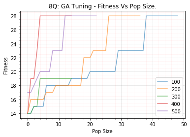

```python
for i in range(0, dfstats_8Q_GA_PopSz.shape[0]):
    plt.plot(dfstats_8Q_GA_PopSz.iloc[i]['Fitness'], label=dfstats_8Q_GA_PopSz.iloc[i]['Pop_Size'], alpha=0.6)

plt.title('8Q: GA Tuning - Fitness Vs Pop Size.')
plt.legend(loc='lower right')
plt.xlabel('Pop Size')
plt.ylabel('Fitness')
plt.minorticks_on()
plt.grid(b=True, which='major', color='k', linestyle='-', alpha=0.1)
plt.grid(b=True, which='minor', color='r', linestyle='-', alpha=0.05)
plt.show()
```

```python
# Simulated Annealing - Decay.

expdecay = mlrose.ExpDecay(init_temp=1.0, exp_const=0.005, min_temp=0.001)
arithdecay = mlrose.ArithDecay(init_temp=1.0, decay=0.0001, min_temp=0.001)
geomdecay = mlrose.GeomDecay(init_temp=1.0, decay=0.99, min_temp=0.001)

algo_stats = []
for decay in [expdecay, arithdecay, geomdecay]:
    t_start = time.time()*1000.0
    best_state, best_fitness, curve_vals = mlrose.simulated_annealing(problem,max_attempts=10,schedule=decay,curve=True,random_state=11)
    t_stop = time.time()*1000.0
    runtime = t_stop - t_start
    algo_stats.append(["Knapsack", "SA", best_state, best_fitness, type(decay).__name__, curve_vals.size, curve_vals, runtime])
```

```python
dfstats_8Q_SA_Decay = pd.DataFrame(algo_stats, columns=['Problem', 'Algorithm', 'Best_State', 'Best_Fitness', 'Decay_Type', 'Iterations', 'Fitness', 'Runtime'])
```

```python
dfstats_8Q_SA_Decay.sort_values(['Best_Fitness', 'Iterations'], ascending=[False, True]).iloc[0]
```

```
Problem                                                  Knapsack
Algorithm                                                      SA
Best_State                               [6, 5, 4, 3, 2, 1, 0, 3]
Best_Fitness                                                   23
Decay_Type                                               ExpDecay
Iterations                                                     59
Fitness         [4.0, 4.0, 6.0, 6.0, 6.0, 6.0, 8.0, 8.0, 9.0, ...
Runtime                                                   25.6365
Name: 0, dtype: object
```

```python
dfstats_8Q_SA_Decay
```

|  | Problem | Algorithm | Best_State | Best_Fitness | Decay_Type | Iterations | Fitness | Runtime |
| --- | --- | --- | --- | --- | --- | --- | --- | --- |
| 0 | Knapsack | SA | [6, 5, 4, 3, 2, 1, 0, 3] | 23.0 | ExpDecay | 59 | [4.0, 4.0, 6.0, 6.0, 6.0, 6.0, 8.0, 8.0, 9.0, ... | 25.636475 |
| 1 | Knapsack | SA | [1, 2, 7, 4, 5, 2, 7, 2] | 17.0 | ArithDecay | 132 | [4.0, 4.0, 6.0, 6.0, 6.0, 6.0, 8.0, 8.0, 9.0, ... | 49.891602 |
| 2 | Knapsack | SA | [6, 5, 4, 3, 2, 1, 0, 3] | 23.0 | GeomDecay | 59 | [4.0, 4.0, 6.0, 6.0, 6.0, 6.0, 8.0, 8.0, 9.0, ... | 19.922119 |

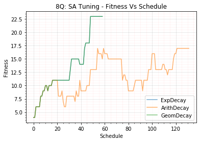

```python
for i in range(0, dfstats_8Q_SA_Decay.shape[0]):
    plt.plot(dfstats_8Q_SA_Decay.iloc[i]['Fitness'], label=dfstats_8Q_SA_Decay.iloc[i]['Decay_Type'], alpha=0.6)

plt.title('8Q: SA Tuning - Fitness Vs Schedule')
plt.legend(loc='lower right')
plt.xlabel('Schedule')
plt.ylabel('Fitness')
plt.minorticks_on()
plt.grid(b=True, which='major', color='k', linestyle='-', alpha=0.1)
plt.grid(b=True, which='minor', color='r', linestyle='-', alpha=0.05)
plt.show()
```

```python
# MIMIC - Keep Pct.
algo_stats = []
for keeppct in (0.1, 0.25, 0.5, 0.75, 1):
    t_start = time.time()*1000.0
    best_state, best_fitness, curve_vals = mlrose.mimic(problem,max_attempts=10,keep_pct=keeppct,curve=True,random_state=11)
    t_stop = time.time()*1000.0
    runtime = t_stop - t_start
    algo_stats.append(["8Q", "MIMIC", best_state, best_fitness, keeppct, curve_vals.size, curve_vals, runtime])
```

```python
dfstats_8Q_MIMIC_KeepPct = pd.DataFrame(algo_stats, columns=['Problem', 'Algorithm', 'Best_State', 'Best_Fitness', 'Keep_Pct', 'Iterations', 'Fitness', 'Runtime'])
```

```python
dfstats_8Q_MIMIC_KeepPct.sort_values(['Best_Fitness', 'Iterations'], ascending=[False, True]).iloc[0]
```

```
Problem                                                        8Q
Algorithm                                                   MIMIC
Best_State                               [2, 7, 6, 5, 4, 3, 2, 1]
Best_Fitness                                                   23
Keep_Pct                                                     0.25
Iterations                                                     14
Fitness         [17.0, 22.0, 22.0, 23.0, 23.0, 23.0, 23.0, 23....
Runtime                                                   1033.76
Name: 1, dtype: object
```

```python
dfstats_8Q_MIMIC_KeepPct
```

|  | Problem | Algorithm | Best_State | Best_Fitness | Keep_Pct | Iterations | Fitness | Runtime |
| --- | --- | --- | --- | --- | --- | --- | --- | --- |
| 0 | 8Q | MIMIC | [7, 6, 5, 4, 3, 2, 7, 6] | 20.0 | 0.10 | 12 | [17.0, 20.0, 20.0, 20.0, 20.0, 20.0, 20.0, 20.... | 895.858643 |
| 1 | 8Q | MIMIC | [2, 7, 6, 5, 4, 3, 2, 1] | 23.0 | 0.25 | 14 | [17.0, 22.0, 22.0, 23.0, 23.0, 23.0, 23.0, 23.... | 1033.760254 |
| 2 | 8Q | MIMIC | [2, 1, 0, 1, 2, 3, 4, 5] | 20.0 | 0.50 | 19 | [14.0, 16.0, 18.0, 18.0, 18.0, 19.0, 19.0, 19.... | 1364.426270 |
| 3 | 8Q | MIMIC | [7, 6, 5, 4, 3, 2, 7, 0] | 23.0 | 0.75 | 24 | [15.0, 15.0, 16.0, 16.0, 19.0, 19.0, 19.0, 19.... | 1778.386963 |
| 4 | 8Q | MIMIC | [2, 3, 4, 6, 6, 7, 3, 3] | 15.0 | 1.00 | 15 | [14.0, 14.0, 14.0, 14.0, 15.0, 15.0, 15.0, 15.... | 1165.885254 |

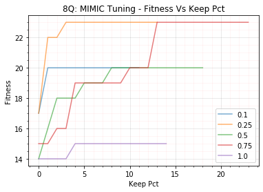

```python
for i in range(0, dfstats_8Q_MIMIC_KeepPct.shape[0]):
    plt.plot(dfstats_8Q_MIMIC_KeepPct.iloc[i]['Fitness'], label=dfstats_8Q_MIMIC_KeepPct.iloc[i]['Keep_Pct'], alpha=0.6)

plt.title('8Q: MIMIC Tuning - Fitness Vs Keep Pct')
plt.legend(loc='lower right')
plt.xlabel('Keep Pct')
plt.ylabel('Fitness')
plt.minorticks_on()
plt.grid(b=True, which='major', color='k', linestyle='-', alpha=0.1)
plt.grid(b=True, which='minor', color='r', linestyle='-', alpha=0.05)
plt.show()
```

```python
# MIMIC - PopSz
algo_stats = []
for popsz in range(100, 600, 100):
    t_start = time.time()*1000.0
    best_state, best_fitness, curve_vals = mlrose.mimic(problem,max_attempts=10,keep_pct=0.25,pop_size=popsz,curve=True,random_state=11)
    t_stop = time.time()*1000.0
    runtime = t_stop - t_start
    algo_stats.append(["8Q", "MIMIC", best_state, best_fitness, popsz, curve_vals.size, curve_vals, runtime])
```

```python
dfstats_8Q_MIMIC_PopSz = pd.DataFrame(algo_stats, columns=['Problem', 'Algorithm', 'Best_State', 'Best_Fitness', 'Pop_Size', 'Iterations', 'Fitness', 'Runtime'])
```

```python
dfstats_8Q_MIMIC_PopSz.sort_values(['Best_Fitness', 'Iterations'], ascending=[False, True]).iloc[0]
```

```
Problem                                                        8Q
Algorithm                                                   MIMIC
Best_State                               [7, 6, 5, 4, 3, 2, 1, 0]
Best_Fitness                                                   28
Pop_Size                                                      500
Iterations                                                     13
Fitness         [19.0, 22.0, 28.0, 28.0, 28.0, 28.0, 28.0, 28....
Runtime                                                   1794.73
Name: 4, dtype: object
```

```python
dfstats_8Q_MIMIC_PopSz
```

|  | Problem | Algorithm | Best_State | Best_Fitness | Pop_Size | Iterations | Fitness | Runtime |
| --- | --- | --- | --- | --- | --- | --- | --- | --- |
| 0 | 8Q | MIMIC | [6, 7, 6, 5, 4, 3, 0, 1] | 19.0 | 100 | 12 | [18.0, 19.0, 19.0, 19.0, 19.0, 19.0, 19.0, 19.... | 635.130859 |
| 1 | 8Q | MIMIC | [2, 7, 6, 5, 4, 3, 2, 1] | 23.0 | 200 | 14 | [17.0, 22.0, 22.0, 23.0, 23.0, 23.0, 23.0, 23.... | 1103.150391 |
| 2 | 8Q | MIMIC | [6, 5, 4, 3, 2, 1, 0, 3] | 23.0 | 300 | 13 | [15.0, 22.0, 23.0, 23.0, 23.0, 23.0, 23.0, 23.... | 1282.782715 |
| 3 | 8Q | MIMIC | [6, 5, 4, 3, 2, 1, 0, 3] | 23.0 | 400 | 12 | [19.0, 23.0, 23.0, 23.0, 23.0, 23.0, 23.0, 23.... | 1400.898682 |
| 4 | 8Q | MIMIC | [7, 6, 5, 4, 3, 2, 1, 0] | 28.0 | 500 | 13 | [19.0, 22.0, 28.0, 28.0, 28.0, 28.0, 28.0, 28.... | 1794.731689 |

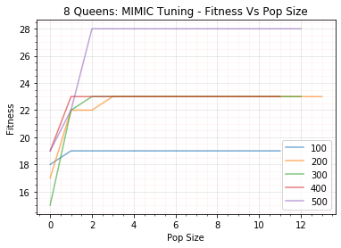

```python
for i in range(0, dfstats_8Q_MIMIC_PopSz.shape[0]):
    plt.plot(dfstats_8Q_MIMIC_PopSz.iloc[i]['Fitness'], label=dfstats_8Q_MIMIC_PopSz.iloc[i]['Pop_Size'], alpha=0.6)

plt.title('8 Queens: MIMIC Tuning - Fitness Vs Pop Size')
plt.legend(loc='lower right')
plt.xlabel('Pop Size')
plt.ylabel('Fitness')
plt.minorticks_on()
plt.grid(b=True, which='major', color='k', linestyle='-', alpha=0.1)
plt.grid(b=True, which='minor', color='r', linestyle='-', alpha=0.05)
plt.show()
```

**Step 2 Observation:** Optimal hyperparameters for each algorithms:

### 3.3 Step 3: Measure Fitness on Tuned Algorithms

All four algorithms were executed for optimal values of their hyperparameters observed in step 2. Hyper Parameters for each algorithms are:

- random_hill_climb: max_iters=np.inf, max_attempts=50 and restarts=2
- simulated_annealing: max_iters=np.inf, max_attempts=10 and schedule=GoemDecay
- genetic_alg: max_iters=np.inf, max_attempts=10, pop_size=400 and mutation_prob=0.25
- mimic: np.inf, max_attempts=10, pop_size=500 and keep_pct=0.25

```python
# Random Hill Climbing
algo_stats = []
t_start = time.time()*1000.0
best_state, best_fitness, curve_vals = mlrose.random_hill_climb(problem,max_attempts=50,restarts=2,curve=True,random_state=11)
t_stop = time.time()*1000.0
runtime = t_stop - t_start
algo_stats.append(["8Queens", "RHC", best_state, best_fitness, 50, curve_vals.size, curve_vals, runtime])

# Genetic Algorithm
t_start = time.time()*1000.0
best_state, best_fitness, curve_vals = mlrose.genetic_alg(problem, max_attempts=10,pop_size=400,mutation_prob=0.25,curve=True,random_state=11)
t_stop = time.time()*1000.0
runtime = t_stop - t_start
algo_stats.append(["8Queens", "GA", best_state, best_fitness, 10, curve_vals.size, curve_vals, runtime])

# Simulated Annealing
t_start = time.time()*1000.0
best_state, best_fitness, curve_vals = mlrose.simulated_annealing(problem,max_attempts=10,schedule=geomdecay,curve=True,random_state=11)
t_stop = time.time()*1000.0
runtime = t_stop - t_start
algo_stats.append(["8Queens", "SA", best_state, best_fitness, 10, curve_vals.size, curve_vals, runtime])

# MIMIC
t_start = time.time()*1000.0
best_state, best_fitness, curve_vals = mlrose.mimic(problem,max_attempts=10,keep_pct=0.25,pop_size=500,curve=True,random_state=11)
t_stop = time.time()*1000.0
runtime = t_stop - t_start
algo_stats.append(["8Queens", "MIMIC", best_state, best_fitness, 10, curve_vals.size, curve_vals, runtime])
```

```python
dfstats_8Q_Opt = pd.DataFrame(algo_stats, columns=['Problem', 'Algorithm', 'Best_State', 'Best_Fitness', 'Max_Attempts', 'Iterations', 'Fitness', 'Runtime'])
```

```python
dfstats_8Q_Opt.sort_values(['Best_Fitness', 'Iterations'], ascending=[False, True]).iloc[0]
```

```
Problem                                                   8Queens
Algorithm                                                   MIMIC
Best_State                               [7, 6, 5, 4, 3, 2, 1, 0]
Best_Fitness                                                   28
Max_Attempts                                                   10
Iterations                                                     13
Fitness         [19.0, 22.0, 28.0, 28.0, 28.0, 28.0, 28.0, 28....
Runtime                                                   1846.81
Name: 3, dtype: object
```

```python
dfstats_8Q_Opt
```

|  | Problem | Algorithm | Best_State | Best_Fitness | Max_Attempts | Iterations | Fitness | Runtime |
| --- | --- | --- | --- | --- | --- | --- | --- | --- |
| 0 | 8Queens | RHC | [6, 5, 4, 3, 2, 1, 0, 3] | 23.0 | 50 | 135 | [6.0, 9.0, 9.0, 9.0, 9.0, 9.0, 10.0, 10.0, 10.... | 110.831055 |
| 1 | 8Queens | GA | [7, 6, 5, 4, 3, 2, 1, 0] | 28.0 | 10 | 15 | [14.0, 19.0, 19.0, 23.0, 28.0, 28.0, 28.0, 28.... | 1834.263184 |
| 2 | 8Queens | SA | [6, 5, 4, 3, 2, 1, 0, 3] | 23.0 | 10 | 59 | [4.0, 4.0, 6.0, 6.0, 6.0, 6.0, 8.0, 8.0, 9.0, ... | 20.940674 |
| 3 | 8Queens | MIMIC | [7, 6, 5, 4, 3, 2, 1, 0] | 28.0 | 10 | 13 | [19.0, 22.0, 28.0, 28.0, 28.0, 28.0, 28.0, 28.... | 1846.813232 |

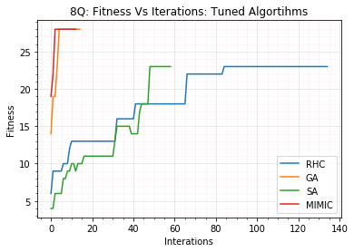

```python
for i in range(0, dfstats_8Q_Opt.shape[0]):
    plt.plot(dfstats_8Q_Opt.iloc[i]['Fitness'], label=dfstats_8Q_Opt.iloc[i]['Algorithm'])

plt.title('8Q: Fitness Vs Iterations: Tuned Algortihms')
plt.legend(loc='lower right')
plt.xlabel('Interations')
plt.ylabel('Fitness')
plt.minorticks_on()
plt.grid(b=True, which='major', color='k', linestyle='-', alpha=0.1)
plt.grid(b=True, which='minor', color='r', linestyle='-', alpha=0.05)
plt.show()
```

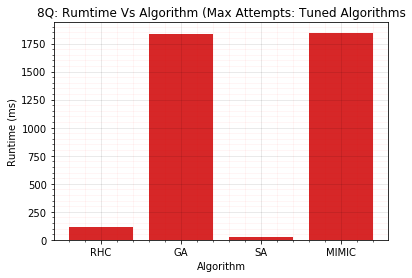

```python
for i in range(0, dfstats_8Q_Opt.shape[0]):
    plt.bar(dfstats_8Q_Opt['Algorithm'], dfstats_8Q_Opt['Runtime'])

plt.title('8Q: Rumtime Vs Algorithm (Max Attempts: Tuned Algorithms')
plt.xlabel('Algorithm')
plt.ylabel('Runtime (ms)')
plt.minorticks_on()
plt.grid(b=True, which='major', color='k', linestyle='-', alpha=0.1)
plt.grid(b=True, which='minor', color='r', linestyle='-', alpha=0.05)
```

Comparision with perfromance in Step 1:  
Perfromance of *Random Hill Climbing* improved from 18.0 to 23.0 and runtime is also increased although number of iteration decreased. Perfromance of *Genetic Algorithm* improved after tunning. Surprisingly runtime of *Genetic Algorithm* increased despite of decrease in the iteration There was no change in the perfromance of the *Simulated Annealing*. Performance of *MIMIC* improved after tunning. Surprisingly runtime of *MIMIC* increased despite of decrease in the iteration.

### 3.4 Step 4: Measure Fitness of Tuned Algorithms on Increased Complexity

Complexity of model was increased by increasing the number of Queens to 50.

```python
size=50
```

```python
# This function is copied from MLRose Tutorial
# https://mlrose.readthedocs.io/en/stable/source/tutorial1.html
def queens_max(state):
    fitness_cnt = 0
    for i in range(len(state) - 1):
        for j in range(i + 1, len(state)):
            if (state[j] != state[i]) and (state[j] != state[i] + (j - i)) and (state[j] != state[i] - (j - i)):
                fitness_cnt += 1
    return fitness_cnt

fitness = mlrose.CustomFitness(queens_max)
```

```python
fitness = mlrose.Queens()
problem = mlrose.DiscreteOpt(length = size, fitness_fn = fitness, maximize = True, max_val = size)
init_state = np.zeros(size)
```

All four algorithms were executed on complex N Queen problem for optimal values of their hyperparameters observed in step 2. Max Iteration and Max Attempts were kept defualt. Hyper Parameters for each algorithms are:

- _random_hill*climb:* restarts=2
- _simulated*annealing:* schedule=GeomDecay
- _genetic*alg:* pop_size=400 and mutation_prob=0.25
- *mimic:* pop_size=500 and keep_pct=0.25

```python
# Random Hill Climbing
algo_stats = []
t_start = time.time()*1000.0
best_state, best_fitness, curve_vals = mlrose.random_hill_climb(problem,restarts=2,curve=True,random_state=11)
t_stop = time.time()*1000.0
runtime = t_stop - t_start
algo_stats.append(["8Queens", "RHC", best_state, best_fitness, 10, curve_vals.size, curve_vals, runtime])

# Genetic Algorithm
t_start = time.time()*1000.0
best_state, best_fitness, curve_vals = mlrose.genetic_alg(problem,pop_size=400,mutation_prob=0.25,curve=True,random_state=11)
t_stop = time.time()*1000.0
runtime = t_stop - t_start
algo_stats.append(["8Queens", "GA", best_state, best_fitness, 10, curve_vals.size, curve_vals, runtime])

# Simulated Annealing
t_start = time.time()*1000.0
best_state, best_fitness, curve_vals = mlrose.simulated_annealing(problem,schedule=geomdecay,curve=True,random_state=11)
t_stop = time.time()*1000.0
runtime = t_stop - t_start
algo_stats.append(["8Queens", "SA", best_state, best_fitness, 10, curve_vals.size, curve_vals, runtime])

# MIMIC
t_start = time.time()*1000.0
best_state, best_fitness, curve_vals = mlrose.mimic(problem,keep_pct=0.25,pop_size=500,curve=True,random_state=11)
t_stop = time.time()*1000.0
runtime = t_stop - t_start
algo_stats.append(["8Queens", "MIMIC", best_state, best_fitness, 10, curve_vals.size, curve_vals, runtime])
```

```python
dfstats_8Q_Opt_Cmplx = pd.DataFrame(algo_stats, columns=['Problem', 'Algorithm', 'Best_State', 'Best_Fitness', 'Max_Attempts', 'Iterations', 'Fitness', 'Runtime'])
```

```python
dfstats_8Q_Opt_Cmplx.sort_values(['Best_Fitness', 'Iterations'], ascending=[False, True]).iloc[0]
```

```
Problem                                                   8Queens
Algorithm                                                   MIMIC
Best_State      [29, 47, 2, 29, 0, 24, 27, 41, 40, 22, 46, 20,...
Best_Fitness                                                  111
Max_Attempts                                                   10
Iterations                                                     26
Fitness         [74.0, 84.0, 88.0, 89.0, 94.0, 98.0, 98.0, 101...
Runtime                                                   48823.5
Name: 3, dtype: object
```

```python
dfstats_8Q_Opt_Cmplx
```

|  | Problem | Algorithm | Best_State | Best_Fitness | Max_Attempts | Iterations | Fitness | Runtime |
| --- | --- | --- | --- | --- | --- | --- | --- | --- |
| 0 | 8Queens | RHC | [25, 16, 27, 17, 13, 20, 33, 7, 33, 24, 0, 28,... | 89.0 | 10 | 112 | [44.0, 44.0, 46.0, 48.0, 48.0, 50.0, 50.0, 52.... | 418.864746 |
| 1 | 8Queens | GA | [22, 22, 1, 0, 31, 42, 19, 19, 49, 45, 49, 30,... | 88.0 | 10 | 12 | [75.0, 88.0, 88.0, 88.0, 88.0, 88.0, 88.0, 88.... | 6308.436523 |
| 2 | 8Queens | SA | [1, 2, 7, 17, 6, 12, 33, 14, 4, 24, 43, 28, 44... | 87.0 | 10 | 117 | [44.0, 44.0, 47.0, 47.0, 46.0, 47.0, 48.0, 48.... | 204.162354 |
| 3 | 8Queens | MIMIC | [29, 47, 2, 29, 0, 24, 27, 41, 40, 22, 46, 20,... | 111.0 | 10 | 26 | [74.0, 84.0, 88.0, 89.0, 94.0, 98.0, 98.0, 101... | 48823.526855 |

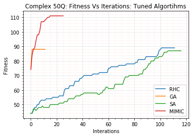

```python
for i in range(0, dfstats_8Q_Opt_Cmplx.shape[0]):
    plt.plot(dfstats_8Q_Opt_Cmplx.iloc[i]['Fitness'], label=dfstats_8Q_Opt_Cmplx.iloc[i]['Algorithm'])

plt.title('Complex 50Q: Fitness Vs Iterations: Tuned Algortihms')
plt.legend(loc='lower right')
plt.xlabel('Interations')
plt.ylabel('Fitness')
plt.minorticks_on()
plt.grid(b=True, which='major', color='k', linestyle='-', alpha=0.1)
plt.grid(b=True, which='minor', color='r', linestyle='-', alpha=0.05)
plt.show()
```

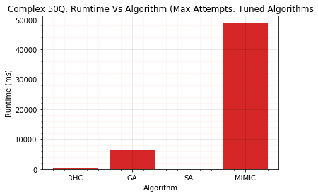

```python
for i in range(0, dfstats_8Q_Opt_Cmplx.shape[0]):
    plt.bar(dfstats_8Q_Opt_Cmplx['Algorithm'], dfstats_8Q_Opt_Cmplx['Runtime'])

plt.title('Complex 50Q: Rumtime Vs Algorithm (Max Attempts: Tuned Algorithms')
plt.xlabel('Algorithm')
plt.ylabel('Runtime (ms)')
plt.minorticks_on()
plt.grid(b=True, which='major', color='k', linestyle='-', alpha=0.1)
plt.grid(b=True, which='minor', color='r', linestyle='-', alpha=0.05)
```

**Step 4 Observation:** For the complex 50 Queen problem *MIMIC* perfromed much better than *Genetic Algorithm* with the best with highest fitness of 111.0. Runtime for *MIMIC* exponentially increased as comapred to *Genetic Algorithm*.

Disadvatanges of MIMIC: Algorithm takes long time to run and runtime increases exponentially with number of iterations it takes to converge.

## 4. Travelling Salesman Problem (modified)

Goal is to find the **longest** tour of the eight cities. As a result, the fitness function should calculate the total length of a given tour. Number of cities: 8

```python
size=8
# Create list of city coordinates
coords_list = [(1, 1), (4, 2), (5, 2), (6, 4), (4, 4), (3, 6), (1, 5), (2, 3)]
```

**Fitness Function:** Fitness function for Travelling Salesman optimization problem. Evaluates the fitness of a tour of n nodes, represented by state vector x, giving the order in which the nodes are visited, as the total distance travelled on the tour (including the distance travelled between the final node in the state vector and the first node in the state vector during the return leg of the tour). Each node must be visited exactly once for a tour to be considered valid. [12]

```python
# Initialize fitness function object using coords_list
fitness = mlrose.TravellingSales(coords = coords_list)
```

```python
problem = mlrose.TSPOpt(length = size, fitness_fn = fitness, maximize = True)
```

### 4.1 Step 1: Measure Fitness with Default Parameters and variable Max_Attempts

All four algorithms were executed with default values of their hyperparameters except max_attempts. Default Parameters for each algorithms are:

- _random_hill*climb:* max_iters=np.inf and restarts=0
- _simulated*annealing:* max_iters=np.inf and schedule=GeomDecay
- _genetic*alg:* max_iters=np.inf, pop_size=200 and mutation_prob=0.1
- *mimic:* np.inf, pop_size=200 and keep_pct=0.2

```python
# Random Hill Climbing
algo_stats = []
for maxampts in range(10, 110, 40):
    t_start = time.time()*1000.0
    best_state, best_fitness, curve_vals = mlrose.random_hill_climb(problem,max_attempts=maxampts,curve=True,random_state=11)
    t_stop = time.time()*1000.0
    runtime = t_stop - t_start
    algo_stats.append(["TSP", "RHC", best_state, best_fitness, maxampts, curve_vals.size, curve_vals, runtime])

# Genetic Algorithm
for maxampts in range(10, 110, 40):
    t_start = time.time()*1000.0
    best_state, best_fitness, curve_vals = mlrose.genetic_alg(problem, max_attempts=maxampts,curve=True,random_state=11)
    t_stop = time.time()*1000.0
    runtime = t_stop - t_start
    algo_stats.append(["TSP", "GA", best_state, best_fitness, maxampts, curve_vals.size, curve_vals, runtime])

# Simulated Annealing
for maxampts in range(10, 110, 40):
    t_start = time.time()*1000.0
    best_state, best_fitness, curve_vals = mlrose.simulated_annealing(problem,max_attempts=maxampts,curve=True,random_state=11)
    t_stop = time.time()*1000.0
    runtime = t_stop - t_start
    algo_stats.append(["TSP", "SA", best_state, best_fitness, maxampts, curve_vals.size, curve_vals, runtime])

# MIMIC
for maxampts in range(10, 110, 40):
    t_start = time.time()*1000.0
    best_state, best_fitness, curve_vals = mlrose.mimic(problem,max_attempts=maxampts,curve=True,random_state=11)
    t_stop = time.time()*1000.0
    runtime = t_stop - t_start
    algo_stats.append(["TSP", "MIMIC", best_state, best_fitness, maxampts, curve_vals.size, curve_vals, runtime])
```

```python
dfstats_TSP = pd.DataFrame(algo_stats, columns=['Problem', 'Algorithm', 'Best_State', 'Best_Fitness', 'Max_Attempts', 'Iterations', 'Fitness', 'Runtime'])
```

```python
dfstats_TSP.sort_values(['Best_Fitness', 'Iterations'], ascending=[False, True]).iloc[0]
```

```
Problem                                                       TSP
Algorithm                                                      GA
Best_State                               [2, 5, 1, 6, 3, 0, 4, 7]
Best_Fitness                                              33.4088
Max_Attempts                                                   10
Iterations                                                     11
Fitness         [33.408840000962066, 33.408840000962066, 33.40...
Runtime                                                    262.17
Name: 3, dtype: object
```

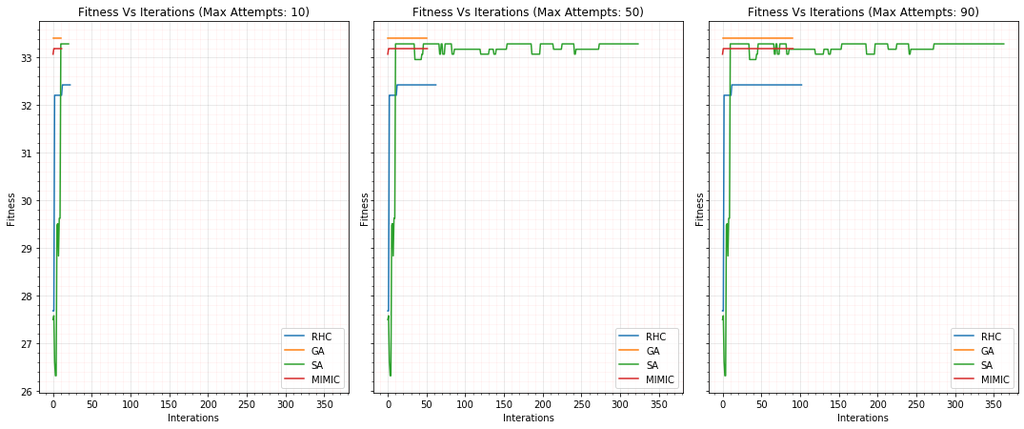

```python
fig, axs = plt.subplots(1,3, figsize=(15, 6), facecolor='w', edgecolor='k', sharex=True, sharey=True)

fig.tight_layout()
for ax, maxampts in zip(axs.ravel(), range(10, 110, 40)):
    for i in range(0, dfstats_TSP[dfstats_KS['Max_Attempts']==maxampts].shape[0]):
        ax.plot(dfstats_TSP[dfstats_TSP['Max_Attempts']==maxampts].iloc[i]['Fitness'], label=dfstats_TSP[dfstats_TSP['Max_Attempts']==maxampts].iloc[i]['Algorithm'])
        ax.set_title('Fitness Vs Iterations (Max Attempts: '+str(maxampts)+')')
        ax.legend(loc='lower right')
        ax.set_xlabel('Interations')
        ax.set_ylabel('Fitness')
        ax.minorticks_on()
        ax.grid(b=True, which='major', color='k', linestyle='-', alpha=0.1)
        ax.grid(b=True, which='minor', color='r', linestyle='-', alpha=0.05)
```

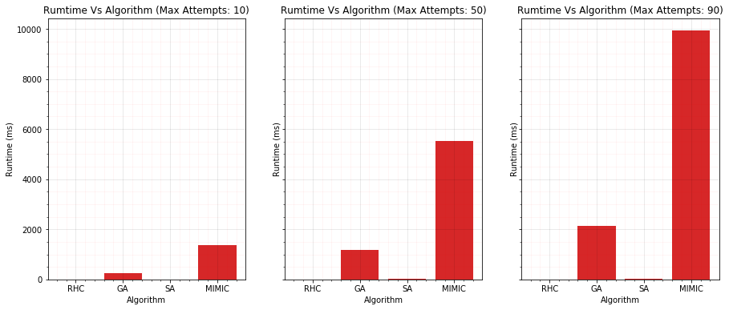

```python
fig, axs = plt.subplots(1,3, figsize=(15, 6), facecolor='w', edgecolor='k', sharex=True, sharey=True)
# fig.tight_layout()
for ax, maxampts in zip(axs.ravel(), range(10, 110, 40)):
    for i in range(0, dfstats_TSP[dfstats_TSP['Max_Attempts']==maxampts].shape[0]):
        ax.bar(dfstats_TSP[dfstats_TSP['Max_Attempts']==maxampts]['Algorithm'],dfstats_TSP[dfstats_TSP['Max_Attempts']==maxampts]['Runtime'])
        ax.set_title('Rumtime Vs Algorithm (Max Attempts: '+str(maxampts)+')')
        ax.set_xlabel('Algorithm')
        ax.set_ylabel('Runtime (ms)')
        ax.minorticks_on()
        ax.grid(b=True, which='major', color='k', linestyle='-', alpha=0.1)
        ax.grid(b=True, which='minor', color='r', linestyle='-', alpha=0.05)
```

```python
dfstats_TSP
```

|  | Problem | Algorithm | Best_State | Best_Fitness | Max_Attempts | Iterations | Fitness | Runtime |
| --- | --- | --- | --- | --- | --- | --- | --- | --- |
| 0 | TSP | RHC | [2, 7, 4, 1, 6, 3, 0, 5] | 32.428258 | 10 | 23 | [27.67695847846789, 27.67695847846789, 32.2097... | 2.991211 |
| 1 | TSP | RHC | [2, 7, 4, 1, 6, 3, 0, 5] | 32.428258 | 50 | 63 | [27.67695847846789, 27.67695847846789, 32.2097... | 4.987793 |
| 2 | TSP | RHC | [2, 7, 4, 1, 6, 3, 0, 5] | 32.428258 | 90 | 103 | [27.67695847846789, 27.67695847846789, 32.2097... | 6.980713 |
| 3 | TSP | GA | [2, 5, 1, 6, 3, 0, 4, 7] | 33.408840 | 10 | 11 | [33.408840000962066, 33.408840000962066, 33.40... | 262.169678 |
| 4 | TSP | GA | [2, 5, 1, 6, 3, 0, 4, 7] | 33.408840 | 50 | 51 | [33.408840000962066, 33.408840000962066, 33.40... | 1179.307129 |
| 5 | TSP | GA | [2, 5, 1, 6, 3, 0, 4, 7] | 33.408840 | 90 | 91 | [33.408840000962066, 33.408840000962066, 33.40... | 2145.003662 |
| 6 | TSP | SA | [4, 1, 6, 2, 5, 0, 3, 7] | 33.290067 | 10 | 21 | [27.492748851486766, 27.57466348470424, 26.612... | 1.994873 |
| 7 | TSP | SA | [5, 2, 6, 1, 4, 7, 3, 0] | 33.290067 | 50 | 324 | [27.492748851486766, 27.57466348470424, 26.612... | 20.163330 |
| 8 | TSP | SA | [5, 2, 6, 1, 4, 7, 3, 0] | 33.290067 | 90 | 364 | [27.492748851486766, 27.57466348470424, 26.612... | 29.672607 |
| 9 | TSP | MIMIC | [0, 3, 7, 1, 5, 2, 6, 4] | 33.190285 | 10 | 12 | [33.073752509869486, 33.19028542586766, 33.190... | 1376.408203 |
| 10 | TSP | MIMIC | [0, 3, 7, 1, 5, 2, 6, 4] | 33.190285 | 50 | 52 | [33.073752509869486, 33.19028542586766, 33.190... | 5528.143799 |
| 11 | TSP | MIMIC | [0, 3, 7, 1, 5, 2, 6, 4] | 33.190285 | 90 | 92 | [33.073752509869486, 33.19028542586766, 33.190... | 9930.217285 |

**Step 1 Observation:** *Genetic Algorithm* perfromed the best with highest fitness of 33.40 and it converged within 11. *MIMIC* perfromed and *Simulated Annealing* were close second but *Simulated Annealing* took 21 iterations whereas *MIMIC* converged only in 12 iterations. On the other hand *Simulated Annealing* was very fast as compared to both *Genetic Algorithm* and *MIMIC*. *Random Hill Climbing* perfromed worst the among four algorithms. Max attempts for all of the algorithms was 10.

### 4.2 Step 2: Hyper Parameter Tuning

# Following hyperparameters were tuned for each algorithms:

- _random_hill*climb:* restarts
- _simulated*annealing:* schedule
- _genetic*alg:* pop_size and mutation_prob
- *mimic:* pop_size and keep_pct

Following hyperparameters were used based on the observations from step 1:

- _random_hill*climb:* max_attempts=10
- _simulated*annealing:* max_attempts=10
- _genetic*alg:* max_attempts=10
- *mimic:* max_attempts=10

```python
# Random Hill Climbing - Restart
algo_stats = []
for rstrt in (0, 1, 2, 3, 4, 5):
    t_start = time.time()*1000.0
    best_state, best_fitness, curve_vals = mlrose.random_hill_climb(problem,max_attempts=10,restarts=rstrt,curve=True,random_state=11)
    t_stop = time.time()*1000.0
    runtime = t_stop - t_start
    algo_stats.append(["TSP", "RHC", best_state, best_fitness, rstrt, curve_vals.size, curve_vals, runtime])
```

```python
dfstats_TSP_RHC_Restart = pd.DataFrame(algo_stats, columns=['Problem', 'Algorithm', 'Best_State', 'Best_Fitness', 'Restarts', 'Iterations', 'Fitness', 'Runtime'])
```

```python
dfstats_TSP_RHC_Restart.sort_values(['Best_Fitness', 'Iterations'], ascending=[False, True]).iloc[0]
```

```
Problem                                                       TSP
Algorithm                                                     RHC
Best_State                               [1, 6, 2, 5, 7, 3, 0, 4]
Best_Fitness                                              33.0738
Restarts                                                        3
Iterations                                                     21
Fitness         [26.891483386175217, 27.352951983056318, 27.35...
Runtime                                                   4.99097
Name: 3, dtype: object
```

```python
dfstats_TSP_RHC_Restart
```

|  | Problem | Algorithm | Best_State | Best_Fitness | Restarts | Iterations | Fitness | Runtime |
| --- | --- | --- | --- | --- | --- | --- | --- | --- |
| 0 | TSP | RHC | [2, 7, 4, 1, 6, 3, 0, 5] | 32.428258 | 0 | 23 | [27.67695847846789, 27.67695847846789, 32.2097... | 3.984863 |
| 1 | TSP | RHC | [2, 7, 4, 1, 6, 3, 0, 5] | 32.428258 | 1 | 23 | [27.67695847846789, 27.67695847846789, 32.2097... | 2.999512 |
| 2 | TSP | RHC | [2, 7, 4, 1, 6, 3, 0, 5] | 32.428258 | 2 | 23 | [27.67695847846789, 27.67695847846789, 32.2097... | 4.980469 |
| 3 | TSP | RHC | [1, 6, 2, 5, 7, 3, 0, 4] | 33.073753 | 3 | 21 | [26.891483386175217, 27.352951983056318, 27.35... | 4.990967 |
| 4 | TSP | RHC | [1, 6, 2, 5, 7, 3, 0, 4] | 33.073753 | 4 | 21 | [26.891483386175217, 27.352951983056318, 27.35... | 7.007324 |
| 5 | TSP | RHC | [1, 6, 2, 5, 7, 3, 0, 4] | 33.073753 | 5 | 21 | [26.891483386175217, 27.352951983056318, 27.35... | 7.973145 |

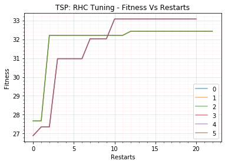

```python
for i in range(0, dfstats_TSP_RHC_Restart.shape[0]):
    plt.plot(dfstats_TSP_RHC_Restart.iloc[i]['Fitness'], label=dfstats_TSP_RHC_Restart.iloc[i]['Restarts'], alpha=0.6)

plt.title('TSP: RHC Tuning - Fitness Vs Restarts')
plt.legend(loc='lower right')
plt.xlabel('Restarts')
plt.ylabel('Fitness')
plt.minorticks_on()
plt.grid(b=True, which='major', color='k', linestyle='-', alpha=0.1)
plt.grid(b=True, which='minor', color='r', linestyle='-', alpha=0.05)
plt.show()
```

```python
# Genetic Algorithm - Mutation Prob.
algo_stats = []
for mutprob in (0.1, 0.25, 0.5):
    t_start = time.time()*1000.0
    best_state, best_fitness, curve_vals = mlrose.genetic_alg(problem,max_attempts=10,mutation_prob=mutprob,curve=True,random_state=11)
    t_stop = time.time()*1000.0
    runtime = t_stop - t_start
    algo_stats.append(["TSP", "GA", best_state, best_fitness, mutprob, curve_vals.size, curve_vals, runtime])
```

```python
dfstats_TSP_GA_MutProb = pd.DataFrame(algo_stats, columns=['Problem', 'Algorithm', 'Best_State', 'Best_Fitness', 'Mutation_Prob', 'Iterations', 'Fitness', 'Runtime'])
```

```python
dfstats_TSP_GA_MutProb.sort_values(['Best_Fitness', 'Iterations'], ascending=[False, True]).iloc[0]
```

```
Problem                                                        TSP
Algorithm                                                       GA
Best_State                                [2, 5, 1, 6, 3, 0, 4, 7]
Best_Fitness                                               33.4088
Mutation_Prob                                                  0.1
Iterations                                                      11
Fitness          [33.408840000962066, 33.408840000962066, 33.40...
Runtime                                                    290.502
Name: 0, dtype: object
```

```python
dfstats_TSP_GA_MutProb
```

|  | Problem | Algorithm | Best_State | Best_Fitness | Mutation_Prob | Iterations | Fitness | Runtime |
| --- | --- | --- | --- | --- | --- | --- | --- | --- |
| 0 | TSP | GA | [2, 5, 1, 6, 3, 0, 4, 7] | 33.40884 | 0.10 | 11 | [33.408840000962066, 33.408840000962066, 33.40... | 290.501709 |
| 1 | TSP | GA | [2, 5, 1, 6, 3, 0, 4, 7] | 33.40884 | 0.25 | 11 | [33.408840000962066, 33.408840000962066, 33.40... | 271.110596 |
| 2 | TSP | GA | [4, 7, 2, 5, 1, 6, 3, 0] | 33.40884 | 0.50 | 25 | [33.29006694721612, 33.29006694721612, 33.2900... | 581.417725 |

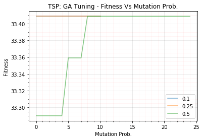

```python
for i in range(0, dfstats_TSP_GA_MutProb.shape[0]):
    plt.plot(dfstats_TSP_GA_MutProb.iloc[i]['Fitness'], label=dfstats_TSP_GA_MutProb.iloc[i]['Mutation_Prob'], alpha=0.6)

plt.title('TSP: GA Tuning - Fitness Vs Mutation Prob.')
plt.legend(loc='lower right')
plt.xlabel('Mutation Prob.')
plt.ylabel('Fitness')
plt.minorticks_on()
plt.grid(b=True, which='major', color='k', linestyle='-', alpha=0.1)
plt.grid(b=True, which='minor', color='r', linestyle='-', alpha=0.05)
plt.show()
```

```python
# Genetic Algorithm - Population Size.
algo_stats = []
for popsz in range(100, 800, 100):
    t_start = time.time()*1000.0
    best_state, best_fitness, curve_vals = mlrose.genetic_alg(problem,max_attempts=10,pop_size=popsz,mutation_prob=0.1,curve=True,random_state=11)
    t_stop = time.time()*1000.0
    runtime = t_stop - t_start
    algo_stats.append(["TSP", "GA", best_state, best_fitness, popsz, curve_vals.size, curve_vals, runtime])
```

```python
dfstats_TSP_GA_PopSz = pd.DataFrame(algo_stats, columns=['Problem', 'Algorithm', 'Best_State', 'Best_Fitness', 'Pop_Size', 'Iterations', 'Fitness', 'Runtime'])
```

```python
dfstats_TSP_GA_PopSz.sort_values(['Best_Fitness', 'Iterations'], ascending=[False, True]).iloc[0]
```

```
Problem                                                       TSP
Algorithm                                                      GA
Best_State                               [2, 5, 1, 6, 3, 0, 4, 7]
Best_Fitness                                              33.4088
Pop_Size                                                      200
Iterations                                                     11
Fitness         [33.408840000962066, 33.408840000962066, 33.40...
Runtime                                                   273.657
Name: 1, dtype: object
```

```python
dfstats_TSP_GA_PopSz
```

|  | Problem | Algorithm | Best_State | Best_Fitness | Pop_Size | Iterations | Fitness | Runtime |
| --- | --- | --- | --- | --- | --- | --- | --- | --- |
| 0 | TSP | GA | [0, 3, 6, 1, 5, 2, 7, 4] | 33.40884 | 100 | 20 | [32.45835304461514, 33.23998963117419, 33.2399... | 264.310303 |
| 1 | TSP | GA | [2, 5, 1, 6, 3, 0, 4, 7] | 33.40884 | 200 | 11 | [33.408840000962066, 33.408840000962066, 33.40... | 273.657227 |
| 2 | TSP | GA | [5, 2, 7, 4, 0, 3, 6, 1] | 33.40884 | 300 | 11 | [33.408840000962066, 33.408840000962066, 33.40... | 484.410889 |
| 3 | TSP | GA | [3, 6, 1, 5, 2, 7, 4, 0] | 33.40884 | 400 | 18 | [33.359135795655526, 33.359135795655526, 33.35... | 879.056396 |
| 4 | TSP | GA | [3, 6, 1, 5, 2, 7, 4, 0] | 33.40884 | 500 | 19 | [33.359135795655526, 33.359135795655526, 33.35... | 1171.219971 |
| 5 | TSP | GA | [1, 6, 3, 0, 4, 7, 2, 5] | 33.40884 | 600 | 19 | [33.359135795655526, 33.359135795655526, 33.35... | 1413.024658 |
| 6 | TSP | GA | [1, 5, 2, 7, 4, 0, 3, 6] | 33.40884 | 700 | 13 | [33.359135795655526, 33.359135795655526, 33.40... | 1126.989502 |

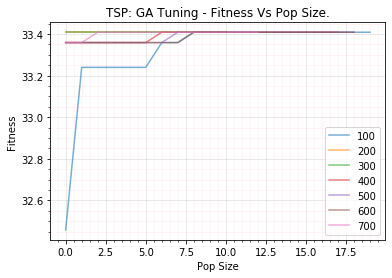

```python
for i in range(0, dfstats_TSP_GA_PopSz.shape[0]):
    plt.plot(dfstats_TSP_GA_PopSz.iloc[i]['Fitness'], label=dfstats_TSP_GA_PopSz.iloc[i]['Pop_Size'], alpha=0.6)

plt.title('TSP: GA Tuning - Fitness Vs Pop Size.')
plt.legend(loc='lower right')
plt.xlabel('Pop Size')
plt.ylabel('Fitness')
plt.minorticks_on()
plt.grid(b=True, which='major', color='k', linestyle='-', alpha=0.1)
plt.grid(b=True, which='minor', color='r', linestyle='-', alpha=0.05)
plt.show()
```

```python
expdecay = mlrose.ExpDecay(init_temp=1.0, exp_const=5, min_temp=0.001)
arithdecay = mlrose.ArithDecay(init_temp=1.0, decay=0.0001, min_temp=0.001)
geomdecay = mlrose.GeomDecay(init_temp=1.0, decay=0.01, min_temp=0.001)

algo_stats = []
for decay in [expdecay, arithdecay, geomdecay]:
    t_start = time.time()*1000.0
    best_state, best_fitness, curve_vals = mlrose.simulated_annealing(problem,max_attempts=10,schedule=decay,curve=True,random_state=11)
    t_stop = time.time()*1000.0
    runtime = t_stop - t_start
    algo_stats.append(["TSP", "SA", best_state, best_fitness, type(decay).__name__, curve_vals.size, curve_vals, runtime])
```

```python
dfstats_TSP_SA_Decay = pd.DataFrame(algo_stats, columns=['Problem', 'Algorithm', 'Best_State', 'Best_Fitness', 'Decay_Type', 'Iterations', 'Fitness', 'Runtime'])
```

```python
dfstats_TSP_SA_Decay.sort_values(['Best_Fitness', 'Iterations'], ascending=[False, True]).iloc[0]
```

```
Problem                                                       TSP
Algorithm                                                      SA
Best_State                               [4, 1, 6, 2, 5, 0, 3, 7]
Best_Fitness                                              33.2901
Decay_Type                                             ArithDecay
Iterations                                                     21
Fitness         [27.492748851486766, 27.57466348470424, 26.612...
Runtime                                                   2.96997
Name: 1, dtype: object
```

```python
dfstats_TSP_SA_Decay
```

|  | Problem | Algorithm | Best_State | Best_Fitness | Decay_Type | Iterations | Fitness | Runtime |
| --- | --- | --- | --- | --- | --- | --- | --- | --- |
| 0 | TSP | SA | [0, 3, 6, 2, 7, 5, 1, 4] | 32.620273 | ExpDecay | 23 | [27.492748851486766, 27.57466348470424, 27.574... | 3.567627 |
| 1 | TSP | SA | [4, 1, 6, 2, 5, 0, 3, 7] | 33.290067 | ArithDecay | 21 | [27.492748851486766, 27.57466348470424, 26.612... | 2.969971 |
| 2 | TSP | SA | [0, 3, 6, 2, 7, 5, 1, 4] | 32.620273 | GeomDecay | 23 | [27.492748851486766, 27.57466348470424, 27.574... | 1.993896 |

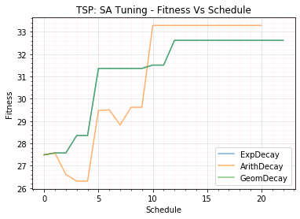

```python
for i in range(0, dfstats_TSP_SA_Decay.shape[0]):
    plt.plot(dfstats_TSP_SA_Decay.iloc[i]['Fitness'], label=dfstats_TSP_SA_Decay.iloc[i]['Decay_Type'], alpha=0.6)

plt.title('TSP: SA Tuning - Fitness Vs Schedule')
plt.legend(loc='lower right')
plt.xlabel('Schedule')
plt.ylabel('Fitness')
plt.minorticks_on()
plt.grid(b=True, which='major', color='k', linestyle='-', alpha=0.1)
plt.grid(b=True, which='minor', color='r', linestyle='-', alpha=0.05)
plt.show()
```

```python
# MIMIC - Keep Pct.
algo_stats = []
for keeppct in (0.1, 0.25, 0.5, 0.75, 1):
    t_start = time.time()*1000.0
    best_state, best_fitness, curve_vals = mlrose.mimic(problem,max_attempts=10,keep_pct=keeppct,curve=True,random_state=11)
    t_stop = time.time()*1000.0
    runtime = t_stop - t_start
    algo_stats.append(["TSP", "MIMIC", best_state, best_fitness, keeppct, curve_vals.size, curve_vals, runtime])
```

```python
dfstats_TSP_MIMIC_KeepPct = pd.DataFrame(algo_stats, columns=['Problem', 'Algorithm', 'Best_State', 'Best_Fitness', 'Keep_Pct', 'Iterations', 'Fitness', 'Runtime'])
```

```python
dfstats_TSP_MIMIC_KeepPct.sort_values(['Best_Fitness', 'Iterations'], ascending=[False, True]).iloc[0]
```

```
Problem                                                       TSP
Algorithm                                                   MIMIC
Best_State                               [0, 3, 6, 1, 5, 2, 7, 4]
Best_Fitness                                              33.4088
Keep_Pct                                                     0.25
Iterations                                                     11
Fitness         [33.408840000962066, 33.408840000962066, 33.40...
Runtime                                                   1222.31
Name: 1, dtype: object
```

```python
dfstats_TSP_MIMIC_KeepPct
```

|  | Problem | Algorithm | Best_State | Best_Fitness | Keep_Pct | Iterations | Fitness | Runtime |
| --- | --- | --- | --- | --- | --- | --- | --- | --- |
| 0 | TSP | MIMIC | [5, 2, 7, 3, 0, 4, 6, 1] | 33.359136 | 0.10 | 11 | [33.359135795655526, 33.359135795655526, 33.35... | 1254.606201 |
| 1 | TSP | MIMIC | [0, 3, 6, 1, 5, 2, 7, 4] | 33.408840 | 0.25 | 11 | [33.408840000962066, 33.408840000962066, 33.40... | 1222.305420 |
| 2 | TSP | MIMIC | [5, 2, 7, 4, 0, 3, 6, 1] | 33.408840 | 0.50 | 15 | [33.19028542586766, 33.19028542586766, 33.1902... | 1752.290039 |
| 3 | TSP | MIMIC | [1, 5, 2, 7, 4, 0, 3, 6] | 33.408840 | 0.75 | 12 | [33.359135795655526, 33.408840000962066, 33.40... | 1370.401611 |
| 4 | TSP | MIMIC | [4, 0, 3, 7, 2, 5, 1, 6] | 33.359136 | 1.00 | 19 | [32.96079015798736, 32.96079015798736, 32.9607... | 2020.216064 |

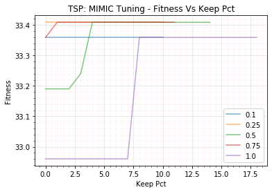

```python
for i in range(0, dfstats_TSP_MIMIC_KeepPct.shape[0]):
    plt.plot(dfstats_TSP_MIMIC_KeepPct.iloc[i]['Fitness'], label=dfstats_TSP_MIMIC_KeepPct.iloc[i]['Keep_Pct'], alpha=0.6)

plt.title('TSP: MIMIC Tuning - Fitness Vs Keep Pct')
plt.legend(loc='lower right')
plt.xlabel('Keep Pct')
plt.ylabel('Fitness')
plt.minorticks_on()
plt.grid(b=True, which='major', color='k', linestyle='-', alpha=0.1)
plt.grid(b=True, which='minor', color='r', linestyle='-', alpha=0.05)
plt.show()
```

```python
# MIMIC - Pop Size.
algo_stats = []
for popsz in range(100, 800, 100):
    t_start = time.time()*1000.0
    best_state, best_fitness, curve_vals = mlrose.mimic(problem,max_attempts=10,keep_pct=0.1,pop_size=popsz,curve=True,random_state=11)
    t_stop = time.time()*1000.0
    runtime = t_stop - t_start
    algo_stats.append(["TSP", "MIMIC", best_state, best_fitness, popsz, curve_vals.size, curve_vals, runtime])
```

```python
dfstats_TSP_MIMIC_PopSz = pd.DataFrame(algo_stats, columns=['Problem', 'Algorithm', 'Best_State', 'Best_Fitness', 'Pop_Size', 'Iterations', 'Fitness', 'Runtime'])
```

```python
dfstats_TSP_MIMIC_PopSz.sort_values(['Best_Fitness', 'Iterations'], ascending=[False, True]).iloc[0]
```

```
Problem                                                       TSP
Algorithm                                                   MIMIC
Best_State                               [0, 3, 6, 1, 5, 2, 7, 4]
Best_Fitness                                              33.4088
Pop_Size                                                      400
Iterations                                                     11
Fitness         [33.408840000962066, 33.408840000962066, 33.40...
Runtime                                                   2209.25
Name: 3, dtype: object
```

```python
dfstats_TSP_MIMIC_PopSz
```

|  | Problem | Algorithm | Best_State | Best_Fitness | Pop_Size | Iterations | Fitness | Runtime |
| --- | --- | --- | --- | --- | --- | --- | --- | --- |
| 0 | TSP | MIMIC | [0, 5, 2, 6, 3, 7, 1, 4] | 32.558135 | 100 | 11 | [32.5581345659636, 32.5581345659636, 32.558134... | 737.254150 |
| 1 | TSP | MIMIC | [5, 2, 7, 3, 0, 4, 6, 1] | 33.359136 | 200 | 11 | [33.359135795655526, 33.359135795655526, 33.35... | 1184.553223 |
| 2 | TSP | MIMIC | [0, 3, 6, 1, 5, 2, 7, 4] | 33.408840 | 300 | 12 | [33.17710459533399, 33.408840000962066, 33.408... | 1828.857178 |
| 3 | TSP | MIMIC | [0, 3, 6, 1, 5, 2, 7, 4] | 33.408840 | 400 | 11 | [33.408840000962066, 33.408840000962066, 33.40... | 2209.245850 |
| 4 | TSP | MIMIC | [7, 4, 1, 6, 2, 5, 0, 3] | 33.290067 | 500 | 12 | [33.17710459533399, 33.29006694721612, 33.2900... | 2872.643799 |
| 5 | TSP | MIMIC | [0, 3, 6, 1, 5, 2, 7, 4] | 33.408840 | 600 | 11 | [33.408840000962066, 33.408840000962066, 33.40... | 3118.077393 |
| 6 | TSP | MIMIC | [5, 2, 7, 4, 0, 3, 6, 1] | 33.408840 | 700 | 11 | [33.408840000962066, 33.408840000962066, 33.40... | 3634.541992 |

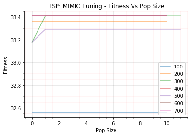

```python
for i in range(0, dfstats_TSP_MIMIC_PopSz.shape[0]):
    plt.plot(dfstats_TSP_MIMIC_PopSz.iloc[i]['Fitness'], label=dfstats_TSP_MIMIC_PopSz.iloc[i]['Pop_Size'], alpha=0.6)

plt.title('TSP: MIMIC Tuning - Fitness Vs Pop Size')
plt.legend(loc='lower right')
plt.xlabel('Pop Size')
plt.ylabel('Fitness')
plt.minorticks_on()
plt.grid(b=True, which='major', color='k', linestyle='-', alpha=0.1)
plt.grid(b=True, which='minor', color='r', linestyle='-', alpha=0.05)
plt.show()
```

**Step 2 Observation:** Optimal hyperparameters for each algorithms: